# pbcData

#Load libraries and data

```r
library(survival)
library(ranger)
library(dplyr)
library(survminer)
library(psych)
library(gmodels)
library(randomForestSRC)
library(tidyverse)
```

```r
library(ggplot2)
library(survxai)
library(fitdistrplus)
library(actuar)
data(pbc,package = "survival")
```

As mentioned in the data description, this data contains information about the clinical trails in primary biliary cirrhosis (PBC) of liver. 312 people participated in the randomized trail and contain largely complete data, an additional 112 followed for survival but for whom only basic measurements have been recorded.

The output is either censored, transplant or dead. (more information about the data can be obtained from typing ‘?pbc’ in the console or refer Appendix of report)

#Data Pre-processing and Analysis ##Preliminary Study

```r
summary(pbc)
```

```
##        id             time          status            trt
##  Min.   :  1.0   Min.   :  41   Min.   :0.0000   Min.   :1.000
##  1st Qu.:105.2   1st Qu.:1093   1st Qu.:0.0000   1st Qu.:1.000
##  Median :209.5   Median :1730   Median :0.0000   Median :1.000
##  Mean   :209.5   Mean   :1918   Mean   :0.8301   Mean   :1.494
##  3rd Qu.:313.8   3rd Qu.:2614   3rd Qu.:2.0000   3rd Qu.:2.000
##  Max.   :418.0   Max.   :4795   Max.   :2.0000   Max.   :2.000
##                                                  NA's   :106
##       age        sex        ascites            hepato          spiders
##  Min.   :26.28   m: 44   Min.   :0.00000   Min.   :0.0000   Min.   :0.0000
##  1st Qu.:42.83   f:374   1st Qu.:0.00000   1st Qu.:0.0000   1st Qu.:0.0000
##  Median :51.00           Median :0.00000   Median :1.0000   Median :0.0000
##  Mean   :50.74           Mean   :0.07692   Mean   :0.5128   Mean   :0.2885
##  3rd Qu.:58.24           3rd Qu.:0.00000   3rd Qu.:1.0000   3rd Qu.:1.0000
##  Max.   :78.44           Max.   :1.00000   Max.   :1.0000   Max.   :1.0000
##                          NA's   :106       NA's   :106      NA's   :106
##      edema             bili             chol           albumin
##  Min.   :0.0000   Min.   : 0.300   Min.   : 120.0   Min.   :1.960
##  1st Qu.:0.0000   1st Qu.: 0.800   1st Qu.: 249.5   1st Qu.:3.243
##  Median :0.0000   Median : 1.400   Median : 309.5   Median :3.530
##  Mean   :0.1005   Mean   : 3.221   Mean   : 369.5   Mean   :3.497
##  3rd Qu.:0.0000   3rd Qu.: 3.400   3rd Qu.: 400.0   3rd Qu.:3.770
##  Max.   :1.0000   Max.   :28.000   Max.   :1775.0   Max.   :4.640
##                                    NA's   :134
##      copper          alk.phos            ast              trig
##  Min.   :  4.00   Min.   :  289.0   Min.   : 26.35   Min.   : 33.00
##  1st Qu.: 41.25   1st Qu.:  871.5   1st Qu.: 80.60   1st Qu.: 84.25
##  Median : 73.00   Median : 1259.0   Median :114.70   Median :108.00
##  Mean   : 97.65   Mean   : 1982.7   Mean   :122.56   Mean   :124.70
##  3rd Qu.:123.00   3rd Qu.: 1980.0   3rd Qu.:151.90   3rd Qu.:151.00
##  Max.   :588.00   Max.   :13862.4   Max.   :457.25   Max.   :598.00
##  NA's   :108      NA's   :106       NA's   :106      NA's   :136
##     platelet        protime          stage
##  Min.   : 62.0   Min.   : 9.00   Min.   :1.000
##  1st Qu.:188.5   1st Qu.:10.00   1st Qu.:2.000
##  Median :251.0   Median :10.60   Median :3.000
##  Mean   :257.0   Mean   :10.73   Mean   :3.024
##  3rd Qu.:318.0   3rd Qu.:11.10   3rd Qu.:4.000
##  Max.   :721.0   Max.   :18.00   Max.   :4.000
##  NA's   :11      NA's   :2       NA's   :6
```

```r
#pbc
```

Modifying the nature of variables

```r
pbc0 <- as_tibble(pbc)
pbc0 <- mutate_at(pbc0, c("id", "status", "trt", "edema", "stage"), factor) #Categorical variables
pbc0 <- mutate_at(pbc0, c("hepato", "ascites", "spiders"), as.logical)
pbc0 <- mutate(pbc0, time = time / 365.25 ) # measure time in years

summary(pbc0)
```

```
##        id           time         status    trt           age        sex
##  1      :  1   Min.   : 0.1123   0:232   1   :158   Min.   :26.28   m: 44
##  2      :  1   1st Qu.: 2.9918   1: 25   2   :154   1st Qu.:42.83   f:374
##  3      :  1   Median : 4.7365   2:161   NA's:106   Median :51.00
##  4      :  1   Mean   : 5.2506                      Mean   :50.74
##  5      :  1   3rd Qu.: 7.1554                      3rd Qu.:58.24
##  6      :  1   Max.   :13.1280                      Max.   :78.44
##  (Other):412
##   ascites          hepato         spiders        edema          bili
##  Mode :logical   Mode :logical   Mode :logical   0  :354   Min.   : 0.300
##  FALSE:288       FALSE:152       FALSE:222       0.5: 44   1st Qu.: 0.800
##  TRUE :24        TRUE :160       TRUE :90        1  : 20   Median : 1.400
##  NA's :106       NA's :106       NA's :106                 Mean   : 3.221
##                                                            3rd Qu.: 3.400
##                                                            Max.   :28.000
##
##       chol           albumin          copper          alk.phos
##  Min.   : 120.0   Min.   :1.960   Min.   :  4.00   Min.   :  289.0
##  1st Qu.: 249.5   1st Qu.:3.243   1st Qu.: 41.25   1st Qu.:  871.5
##  Median : 309.5   Median :3.530   Median : 73.00   Median : 1259.0
##  Mean   : 369.5   Mean   :3.497   Mean   : 97.65   Mean   : 1982.7
##  3rd Qu.: 400.0   3rd Qu.:3.770   3rd Qu.:123.00   3rd Qu.: 1980.0
##  Max.   :1775.0   Max.   :4.640   Max.   :588.00   Max.   :13862.4
##  NA's   :134                      NA's   :108      NA's   :106
##       ast              trig           platelet        protime       stage
##  Min.   : 26.35   Min.   : 33.00   Min.   : 62.0   Min.   : 9.00   1   : 21
##  1st Qu.: 80.60   1st Qu.: 84.25   1st Qu.:188.5   1st Qu.:10.00   2   : 92
##  Median :114.70   Median :108.00   Median :251.0   Median :10.60   3   :155
##  Mean   :122.56   Mean   :124.70   Mean   :257.0   Mean   :10.73   4   :144
##  3rd Qu.:151.90   3rd Qu.:151.00   3rd Qu.:318.0   3rd Qu.:11.10   NA's:  6
##  Max.   :457.25   Max.   :598.00   Max.   :721.0   Max.   :18.00
##  NA's   :106      NA's   :136      NA's   :11      NA's   :2
```

Removing transplant cases from analysis, since it is rare and is highly dependent on donor availability.

```r
# 1 refers to transplant
pbcData <- subset(pbc, status != 1)
pbcData <- transform(pbcData, status = as.logical(status))

pbcData <- mutate(pbcData, time = (pbcData$time / 365.25))

#Factoring values
# sex  : "m" - "Male
#        "f" - "Female"
pbcData$sex <- factor(pbcData$sex
                  , levels = c("m","f")
                  , labels = c("Male", "Female"))
# trt : 1 -  “D-penicillmain”
#       2 -  “placebo”
pbcData$trt <- factor(pbcData$trt #, exclude = NULL
                  , levels = c(1, 2)#, NA)
                  , labels = c("D-penicillmain", "placebo"))#, "NotTreated"))

pbcData <- mutate_at(pbcData, c( "edema", "stage"), factor)
```

##Descriptive Statistics More Analysis on the correlation between the covariates is available in EDA_report.html

```r
describe(pbcData) #describe(pbcData$trt) -- can be used for specific covariate
```

```
##          vars   n    mean      sd  median trimmed    mad    min      max
## id          1 393  206.95  121.69  204.00  206.23 158.64   1.00   418.00
## time        2 393    5.32    3.07    4.84    5.16   3.13   0.11    13.13
## status      3 393     NaN      NA      NA     NaN     NA    Inf     -Inf
## trt*        4 293    1.49    0.50    1.00    1.49   0.00   1.00     2.00
## age         5 393   51.32   10.40   51.92   51.30  11.41  26.28    78.44
## sex*        6 393    1.90    0.31    2.00    1.99   0.00   1.00     2.00
## ascites     7 293    0.08    0.27    0.00    0.00   0.00   0.00     1.00
## hepato      8 293    0.51    0.50    1.00    0.51   0.00   0.00     1.00
## spiders     9 293    0.29    0.45    0.00    0.24   0.00   0.00     1.00
## edema*     10 393    1.21    0.52    1.00    1.07   0.00   1.00     3.00
## bili       11 393    3.20    4.46    1.30    2.11   1.04   0.30    28.00
## chol       12 266  364.77  223.33  303.00  322.64 103.04 120.00  1775.00
## albumin    13 393    3.50    0.42    3.53    3.52   0.40   1.96     4.64
## copper     14 291   95.93   84.50   70.00   82.13  51.89   4.00   588.00
## alk.phos   15 293 2011.67 2195.96 1258.00 1476.99 759.09 289.00 13862.40
## ast        16 293  122.07   57.76  111.00  115.94  51.97  26.35   457.25
## trig       17 264  124.07   64.86  108.00  115.32  46.70  44.00   598.00
## platelet   18 382  253.58   97.19  247.00  247.98  97.11  62.00   721.00
## protime    19 391   10.76    1.04   10.60   10.63   0.89   9.00    18.00
## stage*     20 387    3.01    0.89    3.00    3.08   1.48   1.00     4.00
##             range  skew kurtosis     se
## id         417.00  0.04    -1.22   6.14
## time        13.02  0.44    -0.56   0.15
## status       -Inf    NA       NA     NA
## trt*         1.00  0.02    -2.01   0.03
## age         52.16  0.02    -0.60   0.52
## sex*         1.00 -2.58     4.66   0.02
## ascites      1.00  3.03     7.23   0.02
## hepato       1.00 -0.02    -2.01   0.03
## spiders      1.00  0.92    -1.16   0.03
## edema*       2.00  2.47     5.05   0.03
## bili        27.70  2.69     7.82   0.22
## chol      1655.00  3.28    13.40  13.69
## albumin      2.68 -0.46     0.57   0.02
## copper     584.00  2.30     7.77   4.95
## alk.phos 13573.40  2.88     8.77 128.29
## ast        430.90  1.46     4.12   3.37
## trig       554.00  2.61    12.43   3.99
## platelet   659.00  0.68     1.02   4.97
## protime      9.00  2.17     9.46   0.05
## stage*       3.00 -0.49    -0.67   0.05
```

```r
summary(pbcData) #summary(pbcData$trt)
```

```
##        id           time           status                    trt
##  Min.   :  1   Min.   : 0.1123   Mode :logical   D-penicillmain:148
##  1st Qu.:100   1st Qu.: 3.0637   FALSE:232       placebo       :145
##  Median :204   Median : 4.8433   TRUE :161       NA's          :100
##  Mean   :207   Mean   : 5.3153
##  3rd Qu.:314   3rd Qu.: 7.2745
##  Max.   :418   Max.   :13.1280
##
##       age            sex         ascites            hepato
##  Min.   :26.28   Male  : 41   Min.   :0.00000   Min.   :0.0000
##  1st Qu.:43.94   Female:352   1st Qu.:0.00000   1st Qu.:0.0000
##  Median :51.92                Median :0.00000   Median :1.0000
##  Mean   :51.32                Mean   :0.08191   Mean   :0.5051
##  3rd Qu.:58.82                3rd Qu.:0.00000   3rd Qu.:1.0000
##  Max.   :78.44                Max.   :1.00000   Max.   :1.0000
##                               NA's   :100       NA's   :100
##     spiders       edema          bili             chol           albumin
##  Min.   :0.0000   0  :332   Min.   : 0.300   Min.   : 120.0   Min.   :1.960
##  1st Qu.:0.0000   0.5: 41   1st Qu.: 0.800   1st Qu.: 248.0   1st Qu.:3.260
##  Median :0.0000   1  : 20   Median : 1.300   Median : 303.0   Median :3.530
##  Mean   :0.2901             Mean   : 3.199   Mean   : 364.8   Mean   :3.498
##  3rd Qu.:1.0000             3rd Qu.: 3.300   3rd Qu.: 398.2   3rd Qu.:3.770
##  Max.   :1.0000             Max.   :28.000   Max.   :1775.0   Max.   :4.640
##  NA's   :100                                 NA's   :127
##      copper          alk.phos          ast              trig
##  Min.   :  4.00   Min.   :  289   Min.   : 26.35   Min.   : 44.00
##  1st Qu.: 41.00   1st Qu.:  858   1st Qu.: 79.05   1st Qu.: 84.75
##  Median : 70.00   Median : 1258   Median :111.00   Median :108.00
##  Mean   : 95.93   Mean   : 2012   Mean   :122.07   Mean   :124.07
##  3rd Qu.:123.00   3rd Qu.: 2009   3rd Qu.:151.90   3rd Qu.:151.25
##  Max.   :588.00   Max.   :13862   Max.   :457.25   Max.   :598.00
##  NA's   :102      NA's   :100     NA's   :100      NA's   :129
##     platelet        protime       stage
##  Min.   : 62.0   Min.   : 9.00   1   : 21
##  1st Qu.:182.2   1st Qu.:10.00   2   : 87
##  Median :247.0   Median :10.60   3   :145
##  Mean   :253.6   Mean   :10.76   4   :134
##  3rd Qu.:313.5   3rd Qu.:11.10   NA's:  6
##  Max.   :721.0   Max.   :18.00
##  NA's   :11      NA's   :2
```

## Censored data plot

59% of the data points are right censored observations (232C + 161E )

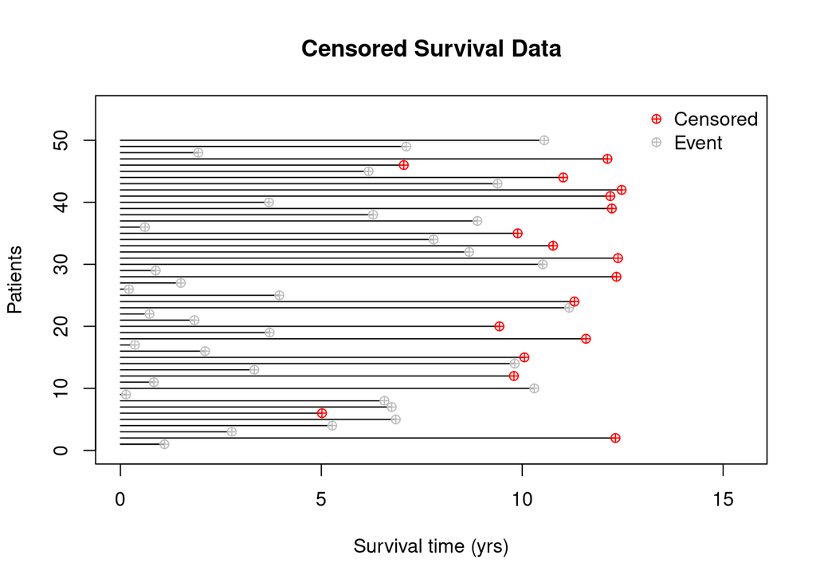

```r
patients <- 50 # change the value to include more or less no of observations in the plot
plot(c(0, pbcData$time[1]), c(1, 1), type = "l"
     , ylim = c(0, patients + 5)
     , xlim = c(0, max(pbcData$time[1:patients]) + 3)
     , ylab = "Patients", xlab = "Survival time (yrs)"
     , main ="Censored Survival Data")
for (i in 1:patients) lines(c(0, pbcData$time[i]), c(i, i)) #?why2:patients
for (i in 1:patients)
    {
        if (pbcData$status[i] == 0)
            points(pbcData$time[i], i, col = "red", pch = 10)  # Censored
        if (pbcData$status[i] == 1)
            points(pbcData$time[i], i, col = "gray", pch = 10) # Event
    }
legend("topright"
       , c("Censored", "Event")
       , pch = 10
       , col = c("red", "gray")
       , bty = "n")
```

The Kaplan–Meier estimator, is a non-parametric statistic used to estimate the survival function from lifetime data. A plot of the Kaplan–Meier estimator is a series of declining horizontal steps which, with a large enough sample size, approaches the true survival function for that population. On the plot, small vertical tick-marks indicate individual patients whose survival times have been right-censored. When no truncation or censoring occurs, the Kaplan–Meier curve is the complement of the empirical distribution function.

#Analysis using Kaplan-Meier Plot

```r
# Create a survival object:
Surv_OBJ <- Surv(pbcData$time, pbcData$status,type= 'right')

# Fitting the survival model - 1 is to estimate based on overall the pbcData:
KM_Model <- survfit(Surv_OBJ ~ 1, data = pbcData, conf.type="log-log", type = "kaplan-meier")

# Show the KM information
KM_Model
```

```
## Call: survfit(formula = Surv_OBJ ~ 1, data = pbcData, conf.type = "log-log",
##     type = "kaplan-meier")
##
##       n  events  median 0.95LCL 0.95UCL
##  393.00  161.00    9.19    7.70   10.30
```

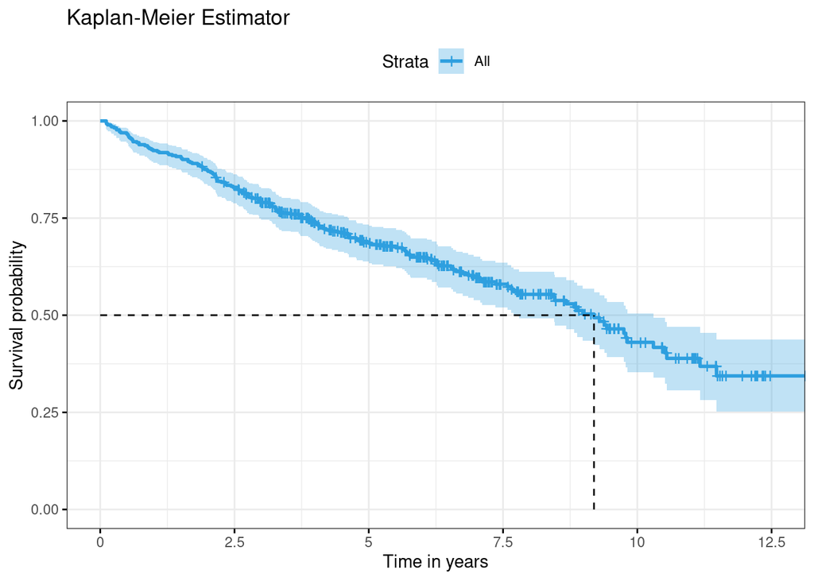

```r
# Plot the Estimators:
ggsurvplot(KM_Model
           ,data = pbcData
           ,xlab = "Time in years"
           ,surv.median.line = "hv"
           ,title="Kaplan-Meier Estimator"
           ,palette = "#2E9FDF"
           ,ggtheme = theme_bw()
           )
```

Median Survival Time - 9.19 years ## What is Kaplan-Meier survival probability over all the data?

```r
summary(KM_Model)
```

```
## Call: survfit(formula = Surv_OBJ ~ 1, data = pbcData, conf.type = "log-log",
##     type = "kaplan-meier")
##
##    time n.risk n.event survival std.err lower 95% CI upper 95% CI
##   0.112    393       2    0.995 0.00359        0.980        0.999
##   0.118    391       1    0.992 0.00439        0.977        0.998
##   0.140    390       1    0.990 0.00506        0.973        0.996
##   0.194    389       1    0.987 0.00565        0.970        0.995
##   0.211    388       1    0.985 0.00619        0.966        0.993
##   0.257    387       1    0.982 0.00667        0.963        0.991
##   0.301    386       1    0.980 0.00712        0.960        0.990
##   0.304    385       1    0.977 0.00755        0.956        0.988
##   0.356    384       1    0.975 0.00794        0.953        0.986
##   0.359    383       1    0.972 0.00832        0.950        0.984
##   0.383    382       1    0.969 0.00868        0.947        0.983
##   0.490    381       1    0.967 0.00902        0.944        0.981
##   0.509    380       1    0.964 0.00935        0.941        0.979
##   0.523    379       1    0.962 0.00967        0.937        0.977
##   0.528    378       1    0.959 0.00997        0.934        0.975
##   0.542    377       1    0.957 0.01026        0.931        0.973
##   0.567    376       1    0.954 0.01055        0.928        0.971
##   0.591    375       1    0.952 0.01082        0.925        0.969
##   0.605    374       1    0.949 0.01109        0.922        0.967
##   0.611    373       1    0.947 0.01134        0.919        0.965
##   0.682    372       1    0.944 0.01160        0.916        0.963
##   0.723    371       2    0.939 0.01208        0.910        0.959
##   0.832    369       1    0.936 0.01231        0.907        0.957
##   0.879    368       1    0.934 0.01254        0.904        0.954
##   0.893    367       1    0.931 0.01276        0.901        0.952
##   0.914    366       1    0.929 0.01298        0.898        0.950
##   0.953    365       1    0.926 0.01319        0.896        0.948
##   0.983    364       1    0.924 0.01339        0.893        0.946
##   1.062    363       1    0.921 0.01360        0.890        0.944
##   1.095    362       1    0.919 0.01380        0.887        0.942
##   1.259    361       1    0.916 0.01399        0.884        0.940
##   1.276    360       1    0.913 0.01418        0.881        0.937
##   1.339    359       1    0.911 0.01437        0.878        0.935
##   1.410    358       1    0.908 0.01455        0.875        0.933
##   1.503    357       1    0.906 0.01473        0.872        0.931
##   1.511    356       1    0.903 0.01491        0.870        0.929
```

[output cut: 105 more lines]

```
##   8.821     62       1    0.521 0.03299        0.454        0.583
##   8.882     59       1    0.512 0.03359        0.444        0.576
##   8.986     57       1    0.503 0.03418        0.434        0.568
##   9.194     54       1    0.494 0.03480        0.424        0.560
##   9.295     52       1    0.484 0.03540        0.413        0.551
##   9.385     50       1    0.475 0.03599        0.403        0.543
##   9.432     49       1    0.465 0.03654        0.392        0.534
##   9.749     41       1    0.453 0.03736        0.379        0.525
##   9.785     40       1    0.442 0.03811        0.366        0.515
##   9.812     37       1    0.430 0.03891        0.353        0.505
##  10.300     33       1    0.417 0.03985        0.339        0.494
##  10.511     30       1    0.403 0.04088        0.323        0.482
##  10.549     28       1    0.389 0.04188        0.307        0.470
##  11.168     19       1    0.368 0.04440        0.282        0.455
##  11.474     15       1    0.344 0.04775        0.252        0.437
```

Specific probabilities

```r
# What is the probability of surviving for 1, 3 and 5 years?
summary(KM_Model,  times = c(1, 3, 5))
```

```
## Call: survfit(formula = Surv_OBJ ~ 1, data = pbcData, conf.type = "log-log",
##     type = "kaplan-meier")
##
##  time n.risk n.event survival std.err lower 95% CI upper 95% CI
##     1    363      30    0.924  0.0134        0.893        0.946
##     3    297      52    0.790  0.0206        0.746        0.827
##     5    189      33    0.689  0.0245        0.638        0.734
```

Now using this model , let us do analysis over a few covariates to understand how are they effecting the survival time.

##KM Survival time - treatment predictor Is there a difference in survival rates between D-penicillmain and placebo?

```r
pbc_trt = pbcData[complete.cases(pbcData$trt), ]

Surv_trt <- Surv(pbc_trt$time, pbc_trt$status)
logRankTest_trt <- survdiff(Surv_trt ~ trt, data = pbc_trt)

logRankTest_trt
```

```
## Call:
## survdiff(formula = Surv_trt ~ trt, data = pbc_trt)
##
##                      N Observed Expected (O-E)^2/E (O-E)^2/V
## trt=D-penicillmain 148       65     63.5    0.0354    0.0722
## trt=placebo        145       60     61.5    0.0366    0.0722
##
##  Chisq= 0.1  on 1 degrees of freedom, p= 0.8
```

```r
# Plot using KM and ggsurvplot
KMLR_trt <- survfit(Surv_trt ~ trt, data = pbc_trt, conf.type="log-log")

KMLR_trt
```

```
## Call: survfit(formula = Surv_trt ~ trt, data = pbc_trt, conf.type = "log-log")
##
##                      n events median 0.95LCL 0.95UCL
## trt=D-penicillmain 148     65   8.82    6.57    11.5
## trt=placebo        145     60   9.30    7.79    10.5
```

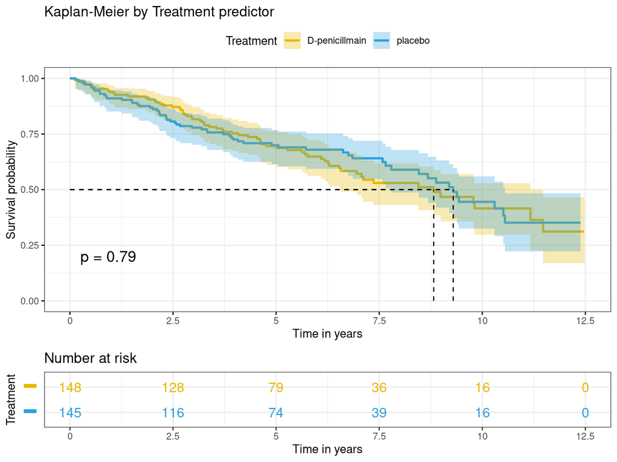

```r
ggsurvplot(KMLR_trt
           ,data = pbc_trt
           ,pval = TRUE
           ,conf.int = TRUE
           #,conf.int.style = "step" # "ribbon"
           ,xlab = "Time in years"
           #,tables.theme = theme_cleantable()
           ,surv.median.line = "hv"
           ,risk.table = TRUE
           ,title="Kaplan-Meier by Treatment predictor"
           ,risk.table.height=.25
           ,tables.col = "strata"
           ,tables.y.text = FALSE
           ,legend.title="Treatment"
           ,palette = c("#E7B800", "#2E9FDF")
           ,ggtheme = theme_bw() # theme_light()
           ,censor = FALSE
           ,legend.labs = c("D-penicillmain", "placebo")

           )
```

Median Survival TIme : D- Pencillmain - 8.82 yrs Placebo - 9.30 yrs and the confidence intervals overlap at a significance level of 5%

p > 5% : Thus we fail to reject the hypothesis that survival times do not vary between D-Pencillmain and placebo

##KM Model- sex Is there a difference of survival times between males and females?

```r
pbc_sex = pbcData[complete.cases(pbcData$sex), ] #remove missing values

Surv_sex <- Surv(pbc_sex$time, pbc_sex$status)
logRankTest_sex <- survdiff(Surv_OBJ ~ sex, data = pbc_sex)

logRankTest_sex
```

```
## Call:
## survdiff(formula = Surv_OBJ ~ sex, data = pbc_sex)
##
##              N Observed Expected (O-E)^2/E (O-E)^2/V
## sex=Male    41       24     17.4     2.529      2.85
## sex=Female 352      137    143.6     0.306      2.85
##
##  Chisq= 2.9  on 1 degrees of freedom, p= 0.09
```

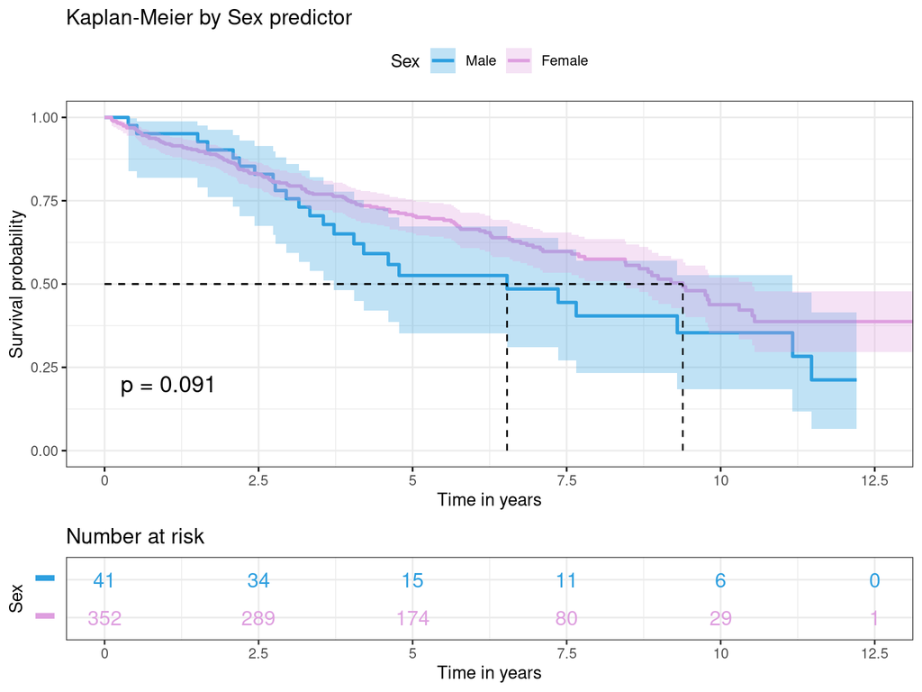

```r
# Plot using KM and ggsurvplot
KMLR_sex <- survfit(Surv_OBJ ~ sex, data = pbc_sex, conf.type="log-log")
ggsurvplot(KMLR_sex
           ,data = pbc_sex
           ,pval = TRUE
           ,conf.int = TRUE
           #,conf.int.style = "step" # "ribbon"
           ,xlab = "Time in years"
           #,tables.theme = theme_cleantable()
           ,surv.median.line = "hv"
           ,risk.table = TRUE
           ,title="Kaplan-Meier by Sex predictor"
           ,risk.table.height=.25
           ,tables.col = "strata"
           ,tables.y.text = FALSE
           ,legend.title="Sex"
           ,palette = c("#2E9FDF", "#DE9FDF")
           ,ggtheme = theme_bw() # theme_light()
           ,censor = FALSE
           ,legend.labs = c("Male", "Female")
           )
```

```r
KMLR_sex
```

```
## Call: survfit(formula = Surv_OBJ ~ sex, data = pbc_sex, conf.type = "log-log")
##
##              n events median 0.95LCL 0.95UCL
## sex=Male    41     24   6.53    3.72    11.2
## sex=Female 352    137   9.39    8.45    10.5
```

p > 5% : Thus we fail to reject the hypothesis that survival times do not vary between males and females

##KM Model - edema

Is there any difference between survival times of different edema factors

```r
pbc_edema = pbcData[complete.cases(pbcData$edema), ]

Surv_edema <- Surv(pbc_edema$time, pbc_edema$status)
logRankTest_edema <- survdiff(Surv_edema ~ edema, data = pbc_edema)

logRankTest_edema
```

```
## Call:
## survdiff(formula = Surv_edema ~ edema, data = pbc_edema)
##
##             N Observed Expected (O-E)^2/E (O-E)^2/V
## edema=0   332      116   145.38      5.94      61.6
## edema=0.5  41       26    13.00     12.99      14.2
## edema=1    20       19     2.61    102.79     105.4
##
##  Chisq= 123  on 2 degrees of freedom, p= <2e-16
```

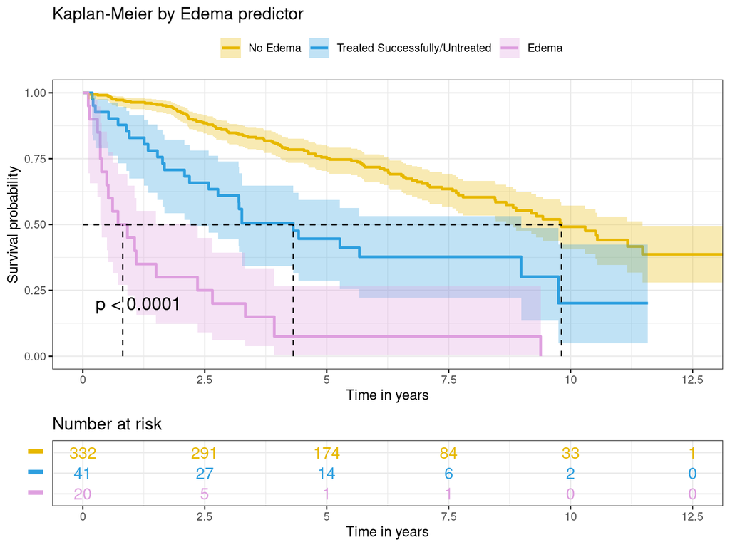

```r
# Plot using KM and ggsurvplot
KMLR_edema <- survfit(Surv_edema ~ edema, data = pbc_edema, conf.type="log-log")
ggsurvplot(KMLR_edema
           ,data = pbc_edema
           ,pval = TRUE
           ,conf.int = TRUE
           ,xlab = "Time in years"
           ,surv.median.line = "hv"
           ,risk.table = TRUE
           ,title="Kaplan-Meier by Edema predictor"
           ,risk.table.height=.25
           ,tables.col = "strata"
           ,tables.y.text = FALSE
           ,legend.title=""
           ,palette = c("#E7B800", "#2E9FDF", "#DE9FDF")
           ,ggtheme = theme_bw() # theme_light()
           ,censor = FALSE
           ,legend.labs = c("No Edema", "Treated Successfully/Untreated", "Edema")

           )
```

p < 5% : Thus we reject the null hypothesis and conclude that a significant difference exists

##KM Model - stage

```r
pbc_stage = pbcData[complete.cases(pbcData$stage), ]

Surv_stage <- Surv(pbc_stage$time, pbc_stage$status)
logRankTest_stage <- survdiff(Surv_stage ~ stage, data = pbc_stage)

logRankTest_stage
```

```
## Call:
## survdiff(formula = Surv_stage ~ stage, data = pbc_stage)
##
##           N Observed Expected (O-E)^2/E (O-E)^2/V
## stage=1  21        2     11.9      8.25      8.99
## stage=2  87       23     44.0     10.01     14.07
## stage=3 145       48     61.2      2.83      4.66
## stage=4 134       84     39.9     48.59     66.12
##
##  Chisq= 71.1  on 3 degrees of freedom, p= 3e-15
```

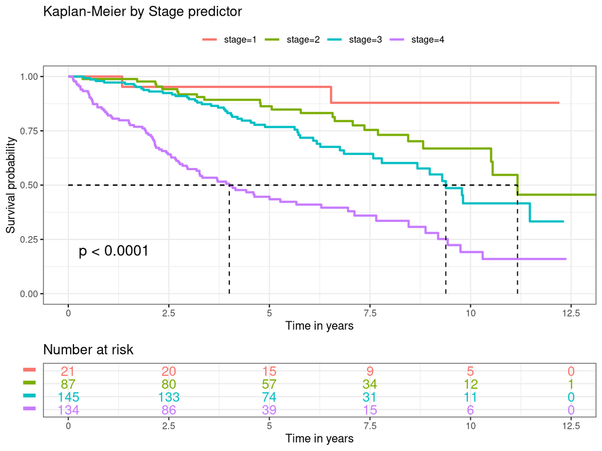

```r
# Plot using KM and ggsurvplot
KMLR_stage <- survfit(Surv_stage ~ stage, data = pbc_stage, conf.type="log-log")
ggsurvplot(KMLR_stage
           ,data = pbc_stage
           ,pval = TRUE
           #,conf.int = TRUE
           ,xlab = "Time in years"
           ,surv.median.line = "hv"
           ,risk.table = TRUE
           ,title="Kaplan-Meier by Stage predictor"
           ,risk.table.height=.25
           ,tables.col = "strata"
           ,tables.y.text = FALSE
           ,legend.title=""
           ,ggtheme = theme_bw() # theme_light()
           ,censor = FALSE

           )
```

We observe an impact of the stage, as expected. In particular, the curvature of the function becomes upward for stage 4, indicating a high mortality in the first years after diagnostic. We also see that survival is almost 100% for patients at stage 1 but the number of patients is quite small at this stage, leading to high uncertainty. To get rid of any doubt on that, we can check whether stage 1 and 2 are significantly different or not :

```r
pbc_temp <- pbc_stage[ pbc_stage$stage %in% c("1", "2"),  ]
logrank_stage <- survdiff( Surv( time, status ) ~ stage, data = pbc_temp )
logrank_stage
```

```
## Call:
## survdiff(formula = Surv(time, status) ~ stage, data = pbc_temp)
##
##          N Observed Expected (O-E)^2/E (O-E)^2/V
## stage=1 21        2     5.45     2.188      2.82
## stage=2 87       23    19.55     0.611      2.82
##
##  Chisq= 2.8  on 1 degrees of freedom, p= 0.09
```

p > 5% : According to the logrank test, we can not reject the hypothesis that survivals at stage 1 and 2 have the same distributions. We decide to merge those 2 levels into a new indicator ‘stageM’. Now we can check the same for stageM and 3.

```r
pbcData$stageM <- fct_collapse(pbcData$stage, "12" = c("1", "2"))
pbc_temp <- pbcData[ pbcData$stageM %in% c("12", "3"),  ]
logrank_stage <- survdiff( Surv( time, status ) ~ stageM, data = pbc_temp )
logrank_stage
```

```
## Call:
## survdiff(formula = Surv(time, status) ~ stageM, data = pbc_temp)
##
##             N Observed Expected (O-E)^2/E (O-E)^2/V
## stageM=12 108       25     36.1      3.42      6.87
## stageM=3  145       48     36.9      3.34      6.87
##
##  Chisq= 6.9  on 1 degrees of freedom, p= 0.009
```

p < 5% : According to the logrank test, we reject the hypothesis that stages 12 and 3 have the same distributions.  
On the other hand, if we compare stages 3 and 4 :

```r
pbc_temp <- pbcData[ pbcData$stageM %in% c("3", "4"),  ]
logrank_stage <- survdiff( Surv( time, status ) ~ stageM, data = pbc_temp )
logrank_stage
```

```
## Call:
## survdiff(formula = Surv(time, status) ~ stageM, data = pbc_temp)
##
##            N Observed Expected (O-E)^2/E (O-E)^2/V
## stageM=3 145       48     79.9      12.7      32.5
## stageM=4 134       84     52.1      19.5      32.5
##
##  Chisq= 32.5  on 1 degrees of freedom, p= 1e-08
```

p << 5% : there is no doubt that according to the stage 3 or 4 of the patient, survival will be different (this is a consequence of the change in curvature).

Explaining Survival with age ##KM Model - age Age variable is made into a categorical variable with groups as follows :

AGE GROUP 20-30 2 30-40 3 40-50 4 50-60 5 60-70 6 70-80 7

```r
pbc_age = pbcData[complete.cases(pbcData$age), ]
pbc_age <- mutate(pbc_age, ageD = floor(age / 10))

Surv_age <- Surv(pbc_age$time, pbc_age$status)
logRankTest_age <- survdiff(Surv_age ~ ageD, data = pbc_age)

logRankTest_age
```

```
## Call:
## survdiff(formula = Surv_age ~ ageD, data = pbc_age)
##
##          N Observed Expected (O-E)^2/E (O-E)^2/V
## ageD=2   3        0     1.66     1.664      1.68
## ageD=3  56       13    23.53     4.715      5.54
## ageD=4 113       42    52.59     2.131      3.21
## ageD=5 133       59    51.94     0.961      1.42
## ageD=6  75       39    27.74     4.571      5.55
## ageD=7  13        8     3.54     5.616      5.77
##
##  Chisq= 19.9  on 5 degrees of freedom, p= 0.001
```

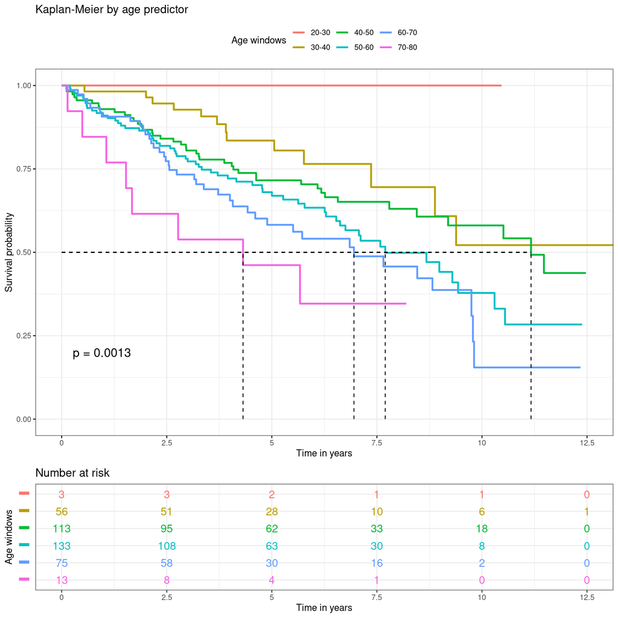

```r
# Plot using KM and ggsurvplot
KMLR_age <- survfit(Surv_age ~ ageD, data = pbc_age, conf.type="log-log")
ggsurvplot(KMLR_age
           ,data = pbc_age
           ,pval = TRUE
           #,conf.int = TRUE
           ,xlab = "Time in years"
           ,surv.median.line = "hv"
           ,risk.table = TRUE
           ,title="Kaplan-Meier by age predictor"
           ,risk.table.height=.25
           ,tables.col = "strata"
           ,tables.y.text = FALSE
           ,legend.title="Age windows"
           ,legend.labs = c("20-30","30-40","40-50","50-60","60-70","70-80")
           ,ggtheme = theme_bw() # theme_light()
           ,censor = FALSE

           )
```

Thus survival differences exist among various age groups

```r
pbc_age <- pbc_age[complete.cases(pbc_age),]
pbc_age_pair <- pairwise_survdiff(formula=Surv(time,status) ~ ageD,data = pbc_age)
pbc_age_pair
```

```
##
##  Pairwise comparisons using Log-Rank test
##
## data:  pbc_age and ageD
##
##   2     3     4     5     6
## 3 0.276 -     -     -     -
## 4 0.336 0.740 -     -     -
## 5 0.216 0.216 0.055 -     -
## 6 0.165 0.053 0.005 0.216 -
## 7 0.185 0.011 0.005 0.068 0.276
##
## P value adjustment method: BH
```

##KM Analysis with pair of variables

###Sex-Age

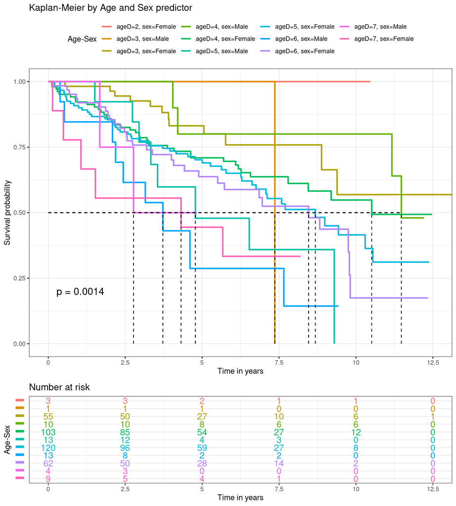

```r
pbc_age_sex = pbcData[complete.cases(pbcData$age,pbcData$sex), ] #remove missing values
pbc_age_sex <- mutate(pbc_age_sex, ageD = floor(age / 10))
Surv_age_sex <- Surv(pbc_age_sex$time, pbc_age_sex$status)

# Plot using KM and ggsurvplot
KMLR_age_sex <- survfit(Surv_age_sex ~ ageD+sex, data = pbc_age_sex, conf.type="log-log")
ggsurvplot(KMLR_age_sex
           ,data = pbc_age_sex
           ,pval = TRUE
           ,conf.int = FALSE
           #,conf.int.style = "step" # "ribbon"
           ,xlab = "Time in years"
           #,tables.theme = theme_cleantable()
           ,surv.median.line = "hv"
           ,risk.table = TRUE
           ,title="Kaplan-Meier by Age and Sex predictor"
           ,risk.table.height=.25
           ,tables.col = "strata"
           ,tables.y.text = FALSE
           ,legend.title="Age-Sex"
           #,palette = c("#2E9FDF", "#DE9FDF")
           ,ggtheme = theme_bw() # theme_light()
           ,censor = FALSE
           #,legend.labs = c("Male", "Female")
           )
```

```r
KMLR_age_sex
```

```
## Call: survfit(formula = Surv_age_sex ~ ageD + sex, data = pbc_age_sex,
##     conf.type = "log-log")
##
##                      n events median 0.95LCL 0.95UCL
## ageD=2, sex=Female   3      0     NA      NA      NA
## ageD=3, sex=Male     1      1   7.36      NA      NA
## ageD=3, sex=Female  55     12     NA    8.88      NA
## ageD=4, sex=Male    10      4  11.47    4.05      NA
## ageD=4, sex=Female 103     38  10.51    7.79      NA
## ageD=5, sex=Male    13      8   4.78    2.95      NA
## ageD=5, sex=Female 120     51   8.68    6.62   10.55
## ageD=6, sex=Male    13      9   3.72    2.09    7.66
## ageD=6, sex=Female  62     30   8.46    4.89    9.79
## ageD=7, sex=Male     4      2   2.77    1.67      NA
## ageD=7, sex=Female   9      6   4.31    0.14      NA
```

```r
joined <- array(1:nrow(pbc_age_sex))

for(i in 1:nrow(pbc_age_sex)){
  if(pbc_age_sex$sex[i]=="Male"){
    if(pbc_age_sex$ageD[i] == "2"){
      joined[i] = "m_2"
    }else if(pbc_age_sex$ageD[i] == "3"){
      joined[i] = "m_3"
    }else if(pbc_age_sex$ageD[i] == "4"){
      joined[i] = "m_4"
    }else if(pbc_age_sex$ageD[i] == "5"){
      joined[i] = "m_5"
    }else if(pbc_age_sex$ageD[i] == "6"){
      joined[i] = "m_6"
    }else{
      joined[i] = "m_7"
    }
  }else{
    if(pbc_age_sex$ageD[i] == "2"){
      joined[i] = "f_2"
    }else if(pbc_age_sex$ageD[i] == "3"){
      joined[i] = "f_3"
    }else if(pbc_age_sex$ageD[i] == "4"){
      joined[i] = "f_4"
    }else if(pbc_age_sex$ageD[i] == "5"){
      joined[i] = "f_5"
    }else if(pbc_age_sex$ageD[i] == "6"){
      joined[i] = "f_6"
    }else{
      joined[i] = "f_7"
    }
  }

}

pbc_age_sex$joined <- joined

pairtest_age_sex <- pairwise_survdiff(formula = Surv(time,status)~joined,data=pbc_age_sex)
pairtest_age_sex
```

```
##
##  Pairwise comparisons using Log-Rank test
##
## data:  pbc_age_sex and joined
##
##     f_2    f_3    f_4    f_5    f_6    f_7    m_3    m_4    m_5    m_6
## f_3 0.4871 -      -      -      -      -      -      -      -      -
## f_4 0.4575 0.3053 -      -      -      -      -      -      -      -
## f_5 0.3806 0.1353 0.4789 -      -      -      -      -      -      -
## f_6 0.2792 0.0752 0.2792 0.6432 -      -      -      -      -      -
## f_7 0.2792 0.0432 0.1319 0.2095 0.2792 -      -      -      -      -
## m_3 0.4871 0.4749 0.5831 0.7363 0.7837 0.7837 -      -      -      -
## m_4 0.5831 0.7837 0.5831 0.2792 0.1519 0.1602 0.4173 -      -      -
## m_5 0.2648 0.0454 0.2648 0.4134 0.4871 0.6425 0.9497 0.1084 -      -
## m_6 0.2126 0.0037 0.0591 0.1209 0.1538 0.8526 0.8097 0.0454 0.5686 -
## m_7 0.3806 0.1888 0.4871 0.5646 0.6354 0.7837 0.5831 0.3637 0.7837 0.7837
##
## P value adjustment method: BH
```

###Sex-Treatment

```r
pbc_sex_trt = pbcData[complete.cases(pbcData$sex,pbcData$trt), ] #remove missing values

Surv_sex_trt <- Surv(pbc_sex_trt$time, pbc_sex_trt$status)
logRankTest_sex_trt<- survdiff(Surv_sex_trt ~ sex+trt, data = pbc_sex_trt)

logRankTest_sex_trt
```

```
## Call:
## survdiff(formula = Surv_sex_trt ~ sex + trt, data = pbc_sex_trt)
##
##                                  N Observed Expected (O-E)^2/E (O-E)^2/V
## sex=Male, trt=D-penicillmain    18       14     7.43     5.812     6.218
## sex=Male, trt=placebo           15        8     7.15     0.102     0.109
## sex=Female, trt=D-penicillmain 130       51    56.07     0.459     0.835
## sex=Female, trt=placebo        130       52    54.35     0.102     0.180
##
##  Chisq= 6.5  on 3 degrees of freedom, p= 0.09
```

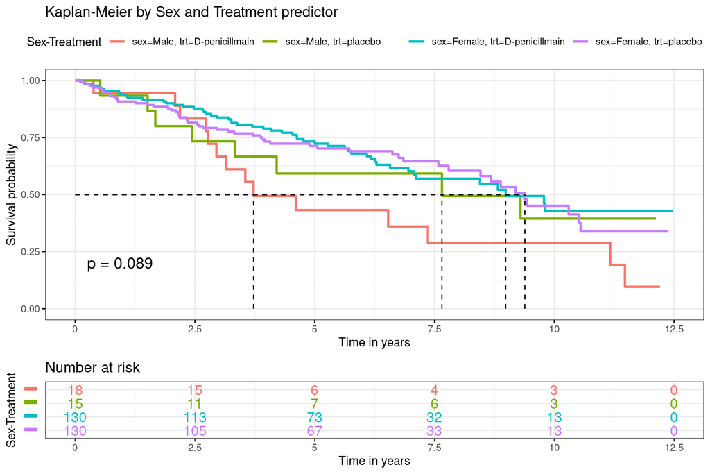

```r
# Plot using KM and ggsurvplot
KMLR_sex_trt <- survfit(Surv_sex_trt ~ sex+trt, data = pbc_sex_trt, conf.type="log-log")
ggsurvplot(KMLR_sex_trt
           ,data = pbc_sex_trt
           ,pval = TRUE
           ,conf.int = FALSE
           #,conf.int.style = "step" # "ribbon"
           ,xlab = "Time in years"
           #,tables.theme = theme_cleantable()
           ,surv.median.line = "hv"
           ,risk.table = TRUE
           ,title="Kaplan-Meier by Sex and Treatment predictor"
           ,risk.table.height=.25
           ,tables.col = "strata"
           ,tables.y.text = FALSE
           ,legend.title="Sex-Treatment"
           #,palette = c("#2E9FDF", "#DE9FDF")
           ,ggtheme = theme_bw() # theme_light()
           ,censor = FALSE
           #,legend.labs = c("Male", "Female")
           )
```

```r
KMLR_sex_trt
```

```
## Call: survfit(formula = Surv_sex_trt ~ sex + trt, data = pbc_sex_trt,
##     conf.type = "log-log")
##
##                                  n events median 0.95LCL 0.95UCL
## sex=Male, trt=D-penicillmain    18     14   3.72    2.77    11.2
## sex=Male, trt=placebo           15      8   7.66    1.67      NA
## sex=Female, trt=D-penicillmain 130     51   8.99    6.95      NA
## sex=Female, trt=placebo        130     52   9.39    7.79    10.5
```

```r
joined <- array(1:nrow(pbc_sex_trt))

for(i in 1:nrow(pbc_sex_trt)){
  if(pbc_sex_trt$sex[i]=="Male"){
    if(pbc_sex_trt$trt[i] == "D-penicillmain"){
      joined[i] = "m_0"
    }else{
      joined[i] = "m_1"
    }
  }else{
    if(pbc_sex_trt$trt[i] == "D-penicillmain"){
      joined[i] = "f_0"
    }else{
      joined[i] = "f_1"
    }
  }

}

pbc_sex_trt$joined <- joined

pairtest_sex_trt <- pairwise_survdiff(formula = Surv(time,status)~joined,data=pbc_sex_trt)
pairtest_sex_trt
```

```
##
##  Pairwise comparisons using Log-Rank test
##
## data:  pbc_sex_trt and joined
##
##     f_0   f_1   m_0
## f_1 0.806 -     -
## m_0 0.066 0.100 -
## m_1 0.754 0.806 0.552
##
## P value adjustment method: BH
```

Earlier we saw that sex and treatment did not have a significant difference on the survival times. However it is the same case when the 2 covariates are paired and tested for difference in survival times.

###Age-Treatment

```r
pbc_age_trt = pbcData[complete.cases(pbcData$age,pbcData$trt), ] #remove missing values
pbc_age_trt <- mutate(pbc_age_trt, ageD = floor(age / 10))
Surv_age_trt <- Surv(pbc_age_trt$time, pbc_age_trt$status)
logRankTest_age_trt<- survdiff(Surv_age_trt ~ ageD+trt, data = pbc_age_trt)

logRankTest_age_trt
```

```
## Call:
## survdiff(formula = Surv_age_trt ~ ageD + trt, data = pbc_age_trt)
##
##                             N Observed Expected (O-E)^2/E (O-E)^2/V
## ageD=2, trt=D-penicillmain  3        0    1.639    1.6387    1.6636
## ageD=3, trt=D-penicillmain 20        5    7.674    0.9318    0.9977
## ageD=3, trt=placebo        27        8   11.673    1.1558    1.2774
## ageD=4, trt=D-penicillmain 38       17   20.561    0.6166    0.7465
## ageD=4, trt=placebo        52       16   24.644    3.0319    3.7964
## ageD=5, trt=D-penicillmain 50       22   21.441    0.0146    0.0176
## ageD=5, trt=placebo        46       23   17.905    1.4499    1.6951
## ageD=6, trt=D-penicillmain 29       17    9.696    5.5023    6.0011
## ageD=6, trt=placebo        17       11    6.840    2.5299    2.6794
## ageD=7, trt=D-penicillmain  8        4    2.489    0.9166    0.9390
## ageD=7, trt=placebo         3        2    0.438    5.5652    5.6000
##
##  Chisq= 23.6  on 10 degrees of freedom, p= 0.009
```

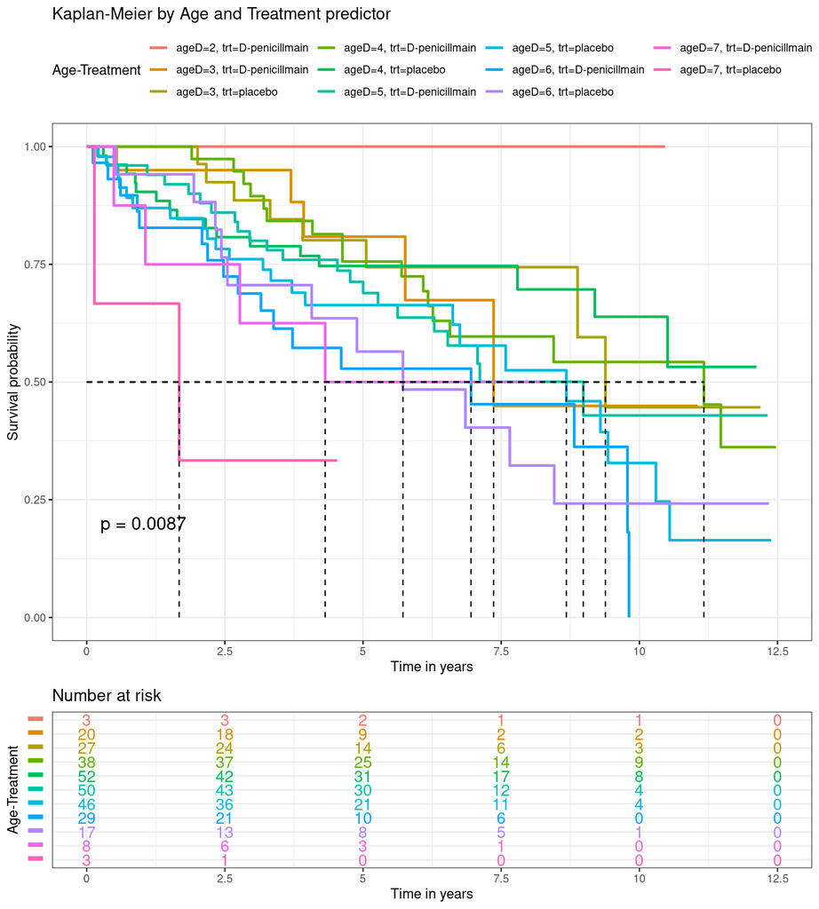

```r
# Plot using KM and ggsurvplot
KMLR_age_trt <- survfit(Surv_age_trt ~ ageD+trt, data = pbc_age_trt, conf.type="log-log")
ggsurvplot(KMLR_age_trt
           ,data = pbc_age_trt
           ,pval = TRUE
           ,conf.int = FALSE
           #,conf.int.style = "step" # "ribbon"
           ,xlab = "Time in years"
           #,tables.theme = theme_cleantable()
           ,surv.median.line = "hv"
           ,risk.table = TRUE
           ,title="Kaplan-Meier by Age and Treatment predictor"
           ,risk.table.height=.25
           ,tables.col = "strata"
           ,tables.y.text = FALSE
           ,legend.title="Age-Treatment"
           #,palette = c("#2E9FDF", "#DE9FDF")
           ,ggtheme = theme_bw() # theme_light()
           ,censor = FALSE
           #,legend.labs = c("Male", "Female")
           )
```

```r
KMLR_age_trt
```

```
## Call: survfit(formula = Surv_age_trt ~ ageD + trt, data = pbc_age_trt,
##     conf.type = "log-log")
##
##                             n events median 0.95LCL 0.95UCL
## ageD=2, trt=D-penicillmain  3      0     NA      NA      NA
## ageD=3, trt=D-penicillmain 20      5   7.36    5.76      NA
## ageD=3, trt=placebo        27      8   9.39    8.88      NA
## ageD=4, trt=D-penicillmain 38     17  11.17    6.18      NA
## ageD=4, trt=placebo        52     16     NA    9.19      NA
## ageD=5, trt=D-penicillmain 50     22   8.99    5.63      NA
## ageD=5, trt=placebo        46     23   8.68    6.62   10.30
## ageD=6, trt=D-penicillmain 29     17   6.95    2.74    9.79
## ageD=6, trt=placebo        17     11   5.72    2.44    8.46
## ageD=7, trt=D-penicillmain  8      4   4.31    0.49      NA
## ageD=7, trt=placebo         3      2   1.67    0.14      NA
```

```r
joined <- array(1:nrow(pbc_age_trt))

for(i in 1:nrow(pbc_age_trt)){
  if(pbc_age_trt$trt[i] == "D-penicillmain"){
    if(pbc_age_trt$ageD[i] == "2"){
      joined[i] = "0_2"
    }else if(pbc_age_trt$ageD[i] == "3"){
      joined[i] = "0_3"
    }else if(pbc_age_trt$ageD[i] == "4"){
      joined[i] = "0_4"
    }else if(pbc_age_trt$ageD[i] == "5"){
      joined[i] = "0_5"
    }else if(pbc_age_trt$ageD[i] == "6"){
      joined[i] = "0_6"
    }else{
      joined[i] = "0_7"
    }
  }else{
    if(pbc_age_trt$ageD[i] == "2"){
      joined[i] = "1_2"
    }else if(pbc_age_trt$ageD[i] == "3"){
      joined[i] = "1_3"
    }else if(pbc_age_trt$ageD[i] == "4"){
      joined[i] = "1_4"
    }else if(pbc_age_trt$ageD[i] == "5"){
      joined[i] = "1_5"
    }else if(pbc_age_trt$ageD[i] == "6"){
      joined[i] = "1_6"
    }else{
      joined[i] = "1_7"
    }
  }

}

pbc_age_trt$joined <- joined

pairtest_age_trt <- pairwise_survdiff(formula = Surv(time,status)~joined,data=pbc_age_trt)
pairtest_age_trt
```

```
##
##  Pairwise comparisons using Log-Rank test
##
## data:  pbc_age_trt and joined
##
##     0_2  0_3  0_4  0_5  0_6  0_7  1_3  1_4  1_5  1_6
## 0_3 0.41 -    -    -    -    -    -    -    -    -
## 0_4 0.41 0.98 -    -    -    -    -    -    -    -
## 0_5 0.38 0.57 0.65 -    -    -    -    -    -    -
## 0_6 0.29 0.23 0.15 0.31 -    -    -    -    -    -
## 0_7 0.38 0.41 0.38 0.59 0.98 -    -    -    -    -
## 1_3 0.41 0.98 0.86 0.50 0.15 0.31 -    -    -    -
## 1_4 0.45 0.98 0.65 0.38 0.12 0.38 0.98 -    -    -
## 1_5 0.34 0.38 0.31 0.65 0.38 0.65 0.32 0.23 -    -
## 1_6 0.31 0.34 0.29 0.38 0.98 0.98 0.29 0.19 0.65 -
## 1_7 0.31 0.15 0.12 0.15 0.38 0.59 0.12 0.23 0.31 0.31
##
## P value adjustment method: BH
```

Treatment didnot have a significant effect on the survival times. On coupling the treatment variable with age groups too, we dont observe a significant effect

#Cox Proportional Hazard Model Semi parametric , robust model. PH Assumption : Hazards are proportional independent of time.

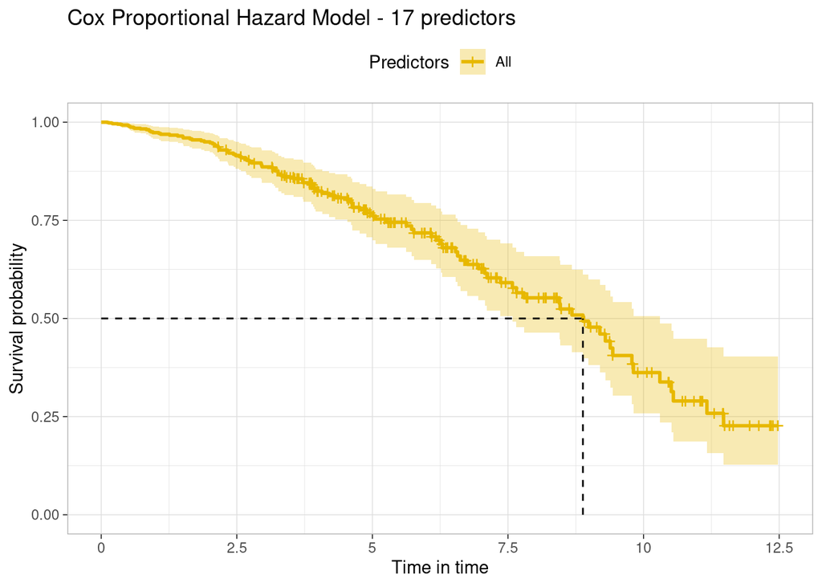

```r
Cox_Data = pbcData[complete.cases(pbcData), ]
Cox_Data <- mutate(Cox_Data, ageD = age/10 )
Surv_Cox <- Surv(Cox_Data$time, Cox_Data$status)

COX_Model <- coxph(Surv_Cox ~ ageD
                 + alk.phos
                 + albumin
                 + ascites
                 + ast
                 + bili
                 + chol
                 + copper
                 + edema
                 + hepato
                 + platelet
                 + protime
                 + sex
                 + spiders
                 + stageM
                 + trt
                 + trig
                 , data = Cox_Data)

# Show the Cox details:
#COX_Model

#Plot Cox curve
ggsurvplot(survfit(COX_Model)
           ,data=Cox_Data
           ,xlab = "Time in time"
           ,title="Cox Proportional Hazard Model - 17 predictors"
           ,ggtheme = theme_light()
           ,legend.title="Predictors"
           ,surv.median.line = "hv"
           #,censor = FALSE
           ,palette = "#E7B800")
```

```r
summary(COX_Model)
```

```
## Call:
## coxph(formula = Surv_Cox ~ ageD + alk.phos + albumin + ascites +
##     ast + bili + chol + copper + edema + hepato + platelet +
##     protime + sex + spiders + stageM + trt + trig, data = Cox_Data)
##
##   n= 258, number of events= 111
##
##                  coef  exp(coef)   se(coef)      z Pr(>|z|)
## ageD        2.610e-01  1.298e+00  1.179e-01  2.214  0.02683 *
## alk.phos   -1.966e-06  1.000e+00  4.080e-05 -0.048  0.96158
## albumin    -7.427e-01  4.758e-01  3.115e-01 -2.384  0.01710 *
## ascites     2.402e-02  1.024e+00  3.976e-01  0.060  0.95184
## ast         3.784e-03  1.004e+00  1.977e-03  1.914  0.05565 .
## bili        7.854e-02  1.082e+00  2.608e-02  3.011  0.00260 **
## chol        4.805e-04  1.000e+00  4.541e-04  1.058  0.28999
## copper      2.588e-03  1.003e+00  1.175e-03  2.204  0.02754 *
## edema0.5    2.714e-01  1.312e+00  3.382e-01  0.802  0.42228
## edema1      1.134e+00  3.109e+00  4.184e-01  2.712  0.00669 **
## hepato      8.197e-02  1.085e+00  2.587e-01  0.317  0.75133
## platelet    8.603e-04  1.001e+00  1.186e-03  0.725  0.46816
## protime     2.165e-01  1.242e+00  1.044e-01  2.074  0.03811 *
## sexFemale  -3.501e-01  7.046e-01  3.074e-01 -1.139  0.25487
## spiders     5.598e-02  1.058e+00  2.503e-01  0.224  0.82303
## stageM3     4.840e-01  1.622e+00  3.247e-01  1.491  0.13604
## stageM4     9.298e-01  2.534e+00  3.854e-01  2.412  0.01585 *
## trtplacebo -1.676e-01  8.457e-01  2.209e-01 -0.759  0.44798
## trig       -5.659e-04  9.994e-01  1.418e-03 -0.399  0.68988
## ---
## Signif. codes:  0 '***' 0.001 '**' 0.01 '*' 0.05 '.' 0.1 ' ' 1
##
##            exp(coef) exp(-coef) lower .95 upper .95
## ageD          1.2982     0.7703    1.0304    1.6356
## alk.phos      1.0000     1.0000    0.9999    1.0001
## albumin       0.4758     2.1017    0.2584    0.8761
## ascites       1.0243     0.9763    0.4699    2.2329
## ast           1.0038     0.9962    0.9999    1.0077
## bili          1.0817     0.9245    1.0278    1.1384
## chol          1.0005     0.9995    0.9996    1.0014
## copper        1.0026     0.9974    1.0003    1.0049
## edema0.5      1.3118     0.7623    0.6761    2.5452
## edema1        3.1095     0.3216    1.3696    7.0598
## hepato        1.0854     0.9213    0.6537    1.8022
## platelet      1.0009     0.9991    0.9985    1.0032
## protime       1.2417     0.8053    1.0119    1.5237
## sexFemale     0.7046     1.4192    0.3857    1.2873
## spiders       1.0576     0.9456    0.6475    1.7273
## stageM3       1.6225     0.6163    0.8587    3.0657
## stageM4       2.5340     0.3946    1.1905    5.3937
## trtplacebo    0.8457     1.1825    0.5485    1.3039
## trig          0.9994     1.0006    0.9967    1.0022
##
## Concordance= 0.844  (se = 0.018 )
## Likelihood ratio test= 162.5  on 19 df,   p=<2e-16
## Wald test            = 169.2  on 19 df,   p=<2e-16
## Score (logrank) test = 279.9  on 19 df,   p=<2e-16
```

There are many non-significant parameters according to wald test but the overall model is significant. Hence it is important to do analysis and select the important parameters.

## Model Building

### Step wise model selection based on AIC

we proceed to a variable selection based on AKIK information criteria which allows comparing models

The Akaike information criterion (AIC) is an estimator of out-of-sample prediction error and thereby relative quality of statistical models for a given set of data. Given a collection of models for the data, AIC estimates the quality of each model, relative to each of the other models. Thus, AIC provides a means for model selection.

Lower the AIC, better the model is.

```r
# using automated process to find the best model
best_cox <- step(COX_Model)
```

```
## Start:  AIC=965.62
## Surv_Cox ~ ageD + alk.phos + albumin + ascites + ast + bili +
##     chol + copper + edema + hepato + platelet + protime + sex +
##     spiders + stageM + trt + trig
##
##            Df    AIC
## - alk.phos  1 963.62
## - ascites   1 963.62
## - spiders   1 963.67
## - hepato    1 963.72
## - trig      1 963.78
## - platelet  1 964.14
## - trt       1 964.19
## - chol      1 964.68
## - sex       1 964.87
## <none>        965.62
## - ast       1 967.06
## - protime   1 967.48
## - stageM    2 967.71
## - copper    1 968.13
## - ageD      1 968.52
## - edema     2 968.63
## - albumin   1 969.17
## - bili      1 971.67
##
## Step:  AIC=963.62
## Surv_Cox ~ ageD + albumin + ascites + ast + bili + chol + copper +
##     edema + hepato + platelet + protime + sex + spiders + stageM +
##     trt + trig
##
##            Df    AIC
## - ascites   1 961.63
## - spiders   1 961.68
## - hepato    1 961.72
## - trig      1 961.78
## - platelet  1 962.15
## - trt       1 962.19
## - chol      1 962.70
## - sex       1 962.87
## <none>        963.62
```

[output cut: 142 more lines]

```
##
## Step:  AIC=951.53
## Surv_Cox ~ ageD + albumin + ast + bili + copper + edema + protime +
##     stageM
##
##           Df    AIC
## <none>       951.53
## - protime  1 953.24
## - edema    2 953.49
## - ast      1 953.89
## - albumin  1 956.10
## - stageM   2 956.16
## - ageD     1 957.02
## - copper   1 957.20
## - bili     1 965.39
```

Starting with a model containing 17 covariates with an AIC value of 965.62, the best cox model obtained contains 8 covariates and has AIC value of 951.53

```r
summary(best_cox)
```

```
## Call:
## coxph(formula = Surv_Cox ~ ageD + albumin + ast + bili + copper +
##     edema + protime + stageM, data = Cox_Data)
##
##   n= 258, number of events= 111
##
##                coef  exp(coef)   se(coef)      z Pr(>|z|)
## ageD      0.2839068  1.3283092  0.1037416  2.737  0.00621 **
## albumin  -0.7356942  0.4791727  0.2806828 -2.621  0.00876 **
## ast       0.0040362  1.0040444  0.0018317  2.204  0.02756 *
## bili      0.0862750  1.0901061  0.0199084  4.334 1.47e-05 ***
## copper    0.0028901  1.0028943  0.0009982  2.895  0.00379 **
## edema0.5  0.1836783  1.2016292  0.3090616  0.594  0.55230
## edema1    0.9036048  2.4684855  0.3571885  2.530  0.01141 *
## protime   0.2047523  1.2272210  0.1003101  2.041  0.04123 *
## stageM3   0.5062763  1.6591017  0.3106686  1.630  0.10318
## stageM4   0.9183798  2.5052282  0.3275993  2.803  0.00506 **
## ---
## Signif. codes:  0 '***' 0.001 '**' 0.01 '*' 0.05 '.' 0.1 ' ' 1
##
##          exp(coef) exp(-coef) lower .95 upper .95
## ageD        1.3283     0.7528    1.0839    1.6278
## albumin     0.4792     2.0869    0.2764    0.8306
## ast         1.0040     0.9960    1.0004    1.0077
## bili        1.0901     0.9173    1.0484    1.1335
## copper      1.0029     0.9971    1.0009    1.0049
## edema0.5    1.2016     0.8322    0.6557    2.2021
## edema1      2.4685     0.4051    1.2257    4.9713
## protime     1.2272     0.8148    1.0082    1.4938
## stageM3     1.6591     0.6027    0.9025    3.0501
## stageM4     2.5052     0.3992    1.3182    4.7610
##
## Concordance= 0.84  (se = 0.019 )
## Likelihood ratio test= 158.6  on 10 df,   p=<2e-16
## Wald test            = 171.6  on 10 df,   p=<2e-16
## Score (logrank) test = 265.1  on 10 df,   p=<2e-16
```

According to the Harrell’s concordance index, 84% of pairs of patients are correctly ordered by the model which is quite good.(the patient with the higher risk score should have a shorter time-to-disease.)

###Wald Test According to the Wald test on each variable, we reject the hypothesis that those coefficients are null except for ‘edema0.5’ (untreated or successfully treated edema), ‘stageM3’ (3rd stage - needs biopsy).

Thus ,we remove (merge accordingly) ‘edema0.5’, ‘stageM3’ because of poor Wald test indicating low impact.

```r
Cox_Data$stageM <- fct_collapse(Cox_Data$stageM,'34'  = c("3", "4"))
Cox_Data$edemaM <- fct_collapse(Cox_Data$edema,'0_0.5'  = c("0", "0.5"))

#Cox_DataM <- mutate(Cox_Data, edemaM = as.integer( as.integer( edema == 1 ) ) )

best_cox <- coxph(formula = Surv_Cox ~ ageD + albumin + ast + bili + copper +
    edemaM + protime + stageM, data = Cox_Data)
summary(best_cox)
```

```
## Call:
## coxph(formula = Surv_Cox ~ ageD + albumin + ast + bili + copper +
##     edemaM + protime + stageM, data = Cox_Data)
##
##   n= 258, number of events= 111
##
##                coef  exp(coef)   se(coef)      z Pr(>|z|)
## ageD      0.3087914  1.3617782  0.1023867  3.016 0.002562 **
## albumin  -0.9076964  0.4034526  0.2593833 -3.499 0.000466 ***
## ast       0.0035148  1.0035210  0.0018336  1.917 0.055257 .
## bili      0.0870242  1.0909231  0.0188943  4.606 4.11e-06 ***
## copper    0.0030317  1.0030363  0.0009946  3.048 0.002303 **
## edemaM1   0.8432027  2.3237975  0.3361458  2.508 0.012126 *
## protime   0.2390142  1.2699966  0.0942923  2.535 0.011250 *
## stageM34  0.6713367  1.9568513  0.2917476  2.301 0.021387 *
## ---
## Signif. codes:  0 '***' 0.001 '**' 0.01 '*' 0.05 '.' 0.1 ' ' 1
##
##          exp(coef) exp(-coef) lower .95 upper .95
## ageD        1.3618     0.7343    1.1142    1.6644
## albumin     0.4035     2.4786    0.2427    0.6708
## ast         1.0035     0.9965    0.9999    1.0071
## bili        1.0909     0.9167    1.0513    1.1321
## copper      1.0030     0.9970    1.0011    1.0050
## edemaM1     2.3238     0.4303    1.2025    4.4908
## protime     1.2700     0.7874    1.0557    1.5278
## stageM34    1.9569     0.5110    1.1046    3.4665
##
## Concordance= 0.839  (se = 0.019 )
## Likelihood ratio test= 155.4  on 8 df,   p=<2e-16
## Wald test            = 169.3  on 8 df,   p=<2e-16
## Score (logrank) test = 261.8  on 8 df,   p=<2e-16
```

Concordance remains same Hazard Ratios:

## What are the top 10 risky cases in the above model?

```r
risk_data <-
  Cox_Data %>%
  mutate(risk_score = predict(best_cox, newdata = Cox_Data, type = "risk"))

# Arrange the data desc. and view the top 5 risks:
risk_data %>%
  arrange(desc(risk_score)) %>%
  head(10)
```

```
##     id      time status            trt      age    sex ascites hepato spiders
## 1  281 0.1122519   TRUE D-penicillmain 65.88364 Female       1      0       0
## 2   23 0.7227926   TRUE        placebo 55.96715 Female       1      1       1
## 3   18 0.3586585   TRUE D-penicillmain 53.93018 Female       0      1       1
## 4  191 0.5913758   TRUE        placebo 52.69268 Female       1      1       1
## 5    1 1.0951403   TRUE D-penicillmain 58.76523 Female       1      1       1
## 6  154 0.3832991   TRUE D-penicillmain 69.37714   Male       0      0       1
## 7   63 2.3518138   TRUE        placebo 46.62834 Female       0      0       1
## 8   10 0.1396304   TRUE        placebo 70.55989 Female       1      0       1
## 9  223 0.9144422   TRUE D-penicillmain 61.24298 Female       1      1       0
## 10  28 1.5030801   TRUE        placebo 44.94730 Female       1      1       1
##    edema bili chol albumin copper alk.phos    ast trig platelet protime stage
## 1      1 17.9  175    2.10    220    705.0 338.00  229       62    12.9     4
## 2      1 17.4  395    2.94    558   6064.8 227.04  191      214    11.7     4
## 3      1 11.4  178    2.80    588    961.0 280.55  200      283    12.4     4
```

[output cut: 18 more lines]

Top 10 risky cases observed are those patients who observed the event - death, which is as expected. 9/10 of them are females and these 7/10 patients lie in the age group of 50-70

##Test for proportional hazard assumption

```r
SRPH  <- cox.zph(best_cox, transform = "km")
SRPH
```

```
##           chisq df      p
## ageD     1.6985  1 0.1925
## albumin  0.0871  1 0.7679
## ast      1.8591  1 0.1727
## bili    10.6338  1 0.0011
## copper   0.0560  1 0.8129
## edemaM   0.3072  1 0.5794
## protime  4.0697  1 0.0437
## stageM   2.1338  1 0.1441
## GLOBAL  19.4626  8 0.0126
```

p<5% reject the null that the variable follows Proportional hazards bili, protime doesnot follow PH Assumption

Preliminary study shows that ‘bili’ and ‘protime’ are dense for small values and a very large interval [Q3, Q4]. It might be useful to transform those variables when trying regression. Let us introduce logarithms of bili, protime to spread their values and see if the model selects these over bili, protime -

```r
best_coxs <- coxph(formula = Surv_Cox ~ ageD + albumin + ast + log2(bili)+bili + copper +
    edemaM + log2(protime)+protime + stageM, data = Cox_Data)
summary(best_coxs)
```

```
## Call:
## coxph(formula = Surv_Cox ~ ageD + albumin + ast + log2(bili) +
##     bili + copper + edemaM + log2(protime) + protime + stageM,
##     data = Cox_Data)
##
##   n= 258, number of events= 111
##
##                    coef exp(coef)  se(coef)      z Pr(>|z|)
## ageD           0.272913  1.313785  0.099173  2.752 0.005925 **
## albumin       -0.789123  0.454243  0.252154 -3.130 0.001751 **
## ast            0.001914  1.001916  0.001906  1.004 0.315239
## log2(bili)     0.595143  1.813291  0.156039  3.814 0.000137 ***
## bili          -0.026019  0.974317  0.036433 -0.714 0.475133
## copper         0.001919  1.001920  0.001092  1.757 0.078953 .
## edemaM1        0.785478  2.193455  0.329905  2.381 0.017269 *
## log2(protime)  1.434219  4.196367  9.489945  0.151 0.879873
## protime        0.051379  1.052722  1.164497  0.044 0.964808
## stageM34       0.484562  1.623464  0.311618  1.555 0.119949
## ---
## Signif. codes:  0 '***' 0.001 '**' 0.01 '*' 0.05 '.' 0.1 ' ' 1
##
##               exp(coef) exp(-coef) lower .95 upper .95
## ageD             1.3138     0.7612 1.082e+00 1.596e+00
## albumin          0.4542     2.2015 2.771e-01 7.446e-01
## ast              1.0019     0.9981 9.982e-01 1.006e+00
## log2(bili)       1.8133     0.5515 1.336e+00 2.462e+00
## bili             0.9743     1.0264 9.072e-01 1.046e+00
## copper           1.0019     0.9981 9.998e-01 1.004e+00
## edemaM1          2.1935     0.4559 1.149e+00 4.187e+00
## log2(protime)    4.1964     0.2383 3.508e-08 5.020e+08
## protime          1.0527     0.9499 1.074e-01 1.032e+01
## stageM34         1.6235     0.6160 8.814e-01 2.990e+00
##
## Concordance= 0.846  (se = 0.019 )
## Likelihood ratio test= 171.4  on 10 df,   p=<2e-16
## Wald test            = 167.1  on 10 df,   p=<2e-16
## Score (logrank) test = 262.4  on 10 df,   p=<2e-16
```

As indicated by the wald test, bili, protime are non significant variables. Now let us check for PH assumption by removing these variables.

```r
best_cox <- coxph(formula = Surv_Cox ~ ageD + albumin + ast + log2(bili)+ copper +
    edemaM + log2(protime) + stageM, data = Cox_Data)
summary(best_cox)
```

```
## Call:
## coxph(formula = Surv_Cox ~ ageD + albumin + ast + log2(bili) +
##     copper + edemaM + log2(protime) + stageM, data = Cox_Data)
##
##   n= 258, number of events= 111
##
##                    coef exp(coef)  se(coef)      z Pr(>|z|)
## ageD           0.279419  1.322362  0.099300  2.814  0.00489 **
## albumin       -0.799419  0.449590  0.253274 -3.156  0.00160 **
## ast            0.001940  1.001942  0.001910  1.016  0.30986
## log2(bili)     0.502671  1.653130  0.086401  5.818 5.96e-09 ***
## copper         0.002017  1.002019  0.001069  1.886  0.05923 .
## edemaM1        0.771037  2.162007  0.328110  2.350  0.01878 *
## log2(protime)  1.789016  5.983562  0.835907  2.140  0.03234 *
## stageM34       0.501741  1.651594  0.300975  1.667  0.09550 .
## ---
## Signif. codes:  0 '***' 0.001 '**' 0.01 '*' 0.05 '.' 0.1 ' ' 1
##
##               exp(coef) exp(-coef) lower .95 upper .95
## ageD             1.3224     0.7562    1.0885    1.6065
## albumin          0.4496     2.2242    0.2737    0.7386
## ast              1.0019     0.9981    0.9982    1.0057
## log2(bili)       1.6531     0.6049    1.3956    1.9582
## copper           1.0020     0.9980    0.9999    1.0041
## edemaM1          2.1620     0.4625    1.1365    4.1129
## log2(protime)    5.9836     0.1671    1.1626   30.7954
## stageM34         1.6516     0.6055    0.9156    2.9792
##
## Concordance= 0.847  (se = 0.019 )
## Likelihood ratio test= 170.9  on 8 df,   p=<2e-16
## Wald test            = 169.7  on 8 df,   p=<2e-16
## Score (logrank) test = 246.2  on 8 df,   p=<2e-16
```

```r
res <- cox.zph(best_cox)
res
```

```
##                chisq df     p
## ageD          1.1314  1 0.287
## albumin       0.0972  1 0.755
## ast           0.8786  1 0.349
## log2(bili)    1.2107  1 0.271
## copper        0.1972  1 0.657
## edemaM        1.1418  1 0.285
## log2(protime) 4.3971  1 0.036
## stageM        1.5316  1 0.216
## GLOBAL        9.4390  8 0.307
```

#Random Forests

A random forest is a non parametric machine learning strategy that can be used for building a risk prediction model in survival analysis. In survival settings, the predictor is an ensemble formed by combining the results of many survival trees. [More details in the Report]

```r
pbcData<- mutate(pbcData,ageD = age/10)
# Drop rows with NA values from the dataset
RF_Data = pbcData[complete.cases(pbcData), ][,-c(1)]
# Fitting the random forest
RF_Model <- ranger(Surv(RF_Data$time
                            , RF_Data$status) ~.
                       ,data = RF_Data
                       , num.trees = 500
                       , importance = "permutation"
                       ,seed = 1)

# Get the variable importance
data.frame(sort(RF_Model$variable.importance
                ,decreasing = TRUE))
```

```
##          sort.RF_Model.variable.importance..decreasing...TRUE.
## bili                                              0.0815126091
## copper                                            0.0202443774
## ascites                                           0.0111205735
## albumin                                           0.0109929877
## edema                                             0.0106685800
## chol                                              0.0101253147
## ageD                                              0.0077228244
## age                                               0.0075598086
## protime                                           0.0059722662
## ast                                               0.0050467505
## stage                                             0.0042180282
## stageM                                            0.0039999328
## hepato                                            0.0023727802
## alk.phos                                          0.0019014969
## spiders                                           0.0017365378
## trig                                              0.0017261722
## sex                                               0.0004059397
## trt                                              -0.0001975142
## platelet                                         -0.0007474162
```

## Plot the death times

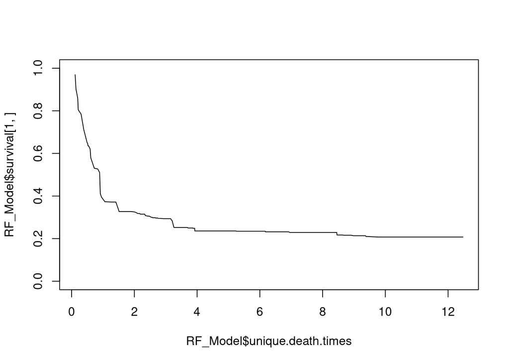

```r
plot(RF_Model$unique.death.times
     , RF_Model$survival[1,]
     , type = "l", ylim = c(0,1)
     ,)
```

# Comparing models: KM_Model,best_cox,RF_Model

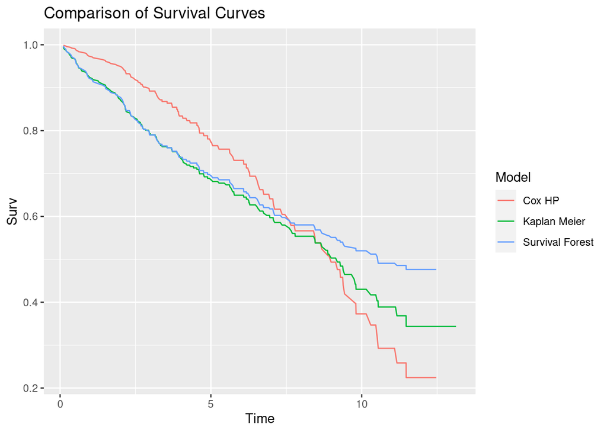

```r
# Add a row of model name
km <- rep("Kaplan Meier", length(KM_Model$time))
cox_surv <- survfit(best_cox)
cox <- rep("Cox HP", length(cox_surv$time))
rf <- rep("Survival Forest",length(RF_Model$unique.death.times))
# Create a dataframe
km_df <- data.frame(KM_Model$time, KM_Model$surv, km)
cox_df <- data.frame(cox_surv$time, cox_surv$surv, cox)
rf_df <- data.frame(RF_Model$unique.death.times,sapply(data.frame(RF_Model$survival),mean),rf)
# Rename the columns so they are same for all dataframes
names(km_df) <- c("Time","Surv","Model")
names(cox_df) <- c("Time","Surv","Model")
names(rf_df) <- c("Time","Surv","Model")
# Combine the results
plot_combo <- rbind(km_df,cox_df,rf_df)

# Make a ggplot
plot_gg <- ggplot(plot_combo, aes(x = Time, y = Surv, color = Model))
plot_gg + geom_line() + ggtitle("Comparison of Survival Curves")
```

#Train and Test split

```r
pbcData<- mutate(pbcData,ageD = age/10)
pbcData = pbcData[complete.cases(pbcData), ]
train_size = floor(0.8*nrow(pbcData))
set.seed(123)
train_ind <- sample(seq_len(nrow(pbcData)), size = train_size)

train <- pbcData[train_ind,]
test <- pbcData[-train_ind,]
```

#Parametric Survival Regression Model

##Check for Probability Distribution

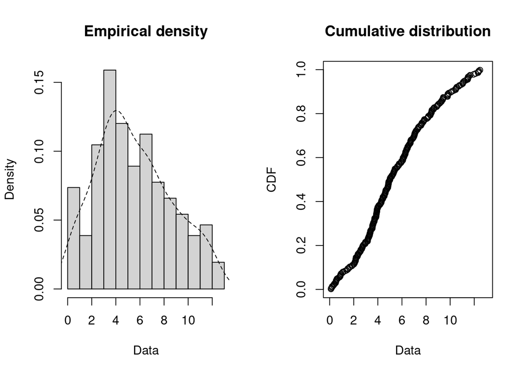

```r
plotdist(pbcData$time, histo = TRUE, demp = TRUE)
```

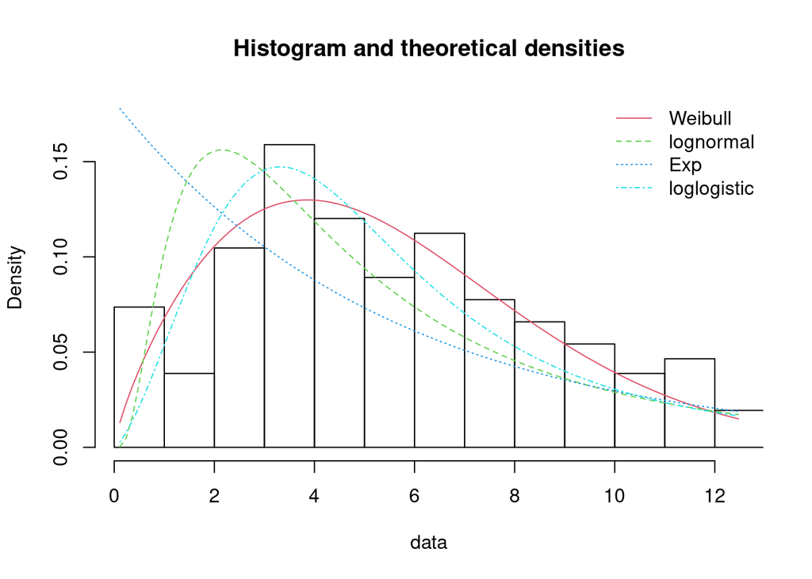

```r
fw <- fitdist(pbcData$time, "weibull")
fln <- fitdist(pbcData$time, "lnorm")
fe <- fitdist(pbcData$time, "exp")
fll<- fitdist(pbcData$time, "llogis",start = list(shape = 1, scale = 500))

plot.legend <- c("Weibull", "lognormal","Exp","loglogistic")
denscomp(list(fw, fln,fe,fll), legendtext = plot.legend)
```

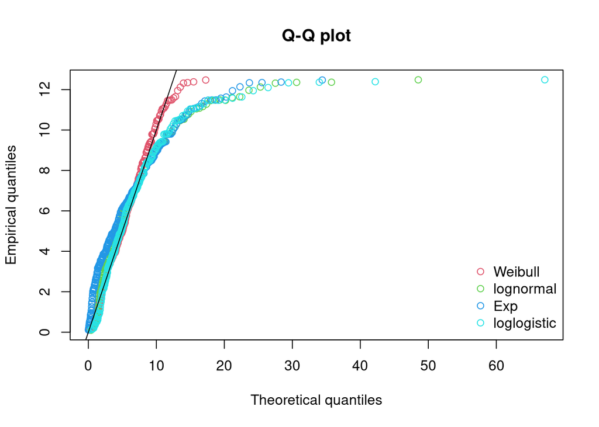

```r
qqcomp(list(fw, fln, fe,fll), legendtext = plot.legend)
```

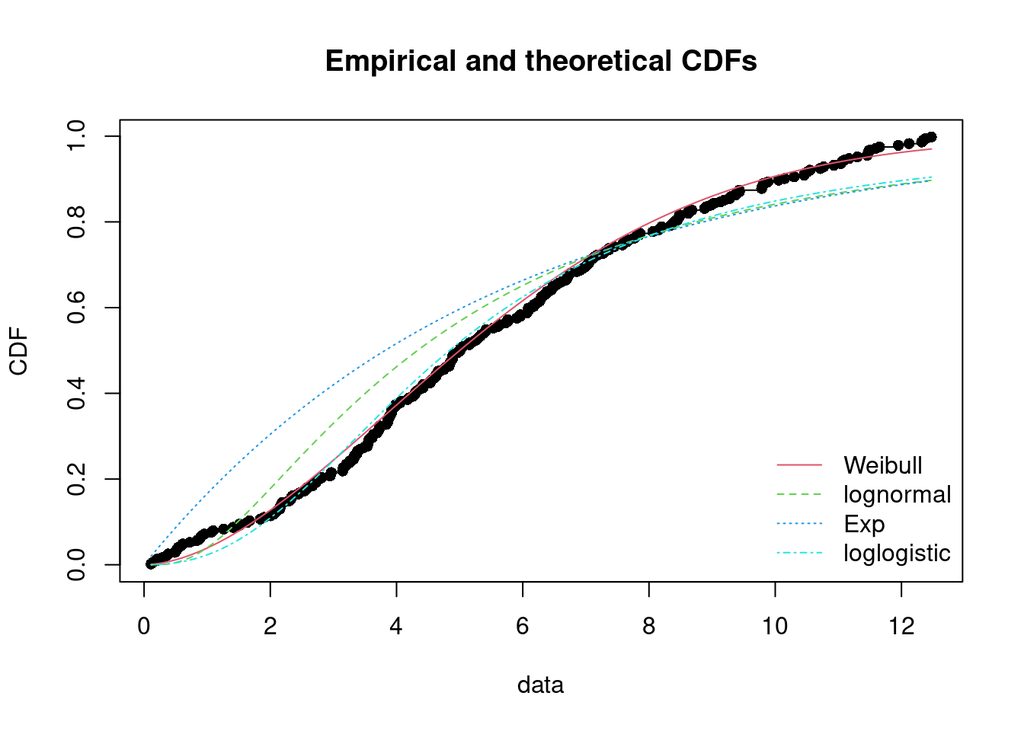

```r
cdfcomp(list(fw, fln,fe,fll), legendtext = plot.legend)
```

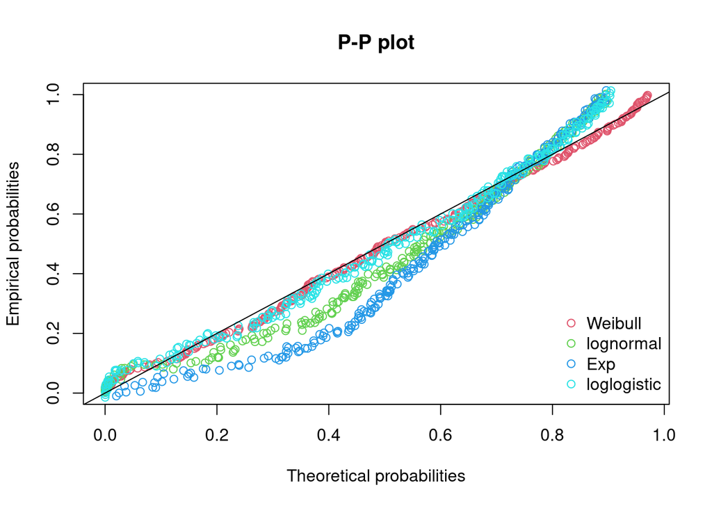

```r
ppcomp(list(fw, fln,fe,fll), legendtext = plot.legend)
```

```r
summary(fw)
```

```
## Fitting of the distribution ' weibull ' by maximum likelihood
## Parameters :
##       estimate Std. Error
## shape 1.774467 0.08995366
## scale 6.148157 0.22574893
## Loglikelihood:  -648.5503   AIC:  1301.101   BIC:  1308.206
## Correlation matrix:
##           shape     scale
## shape 1.0000000 0.2948106
## scale 0.2948106 1.0000000
```

```r
summary(fln)
```

```
## Fitting of the distribution ' lnorm ' by maximum likelihood
## Parameters :
##          estimate Std. Error
## meanlog 1.4660383 0.05208034
## sdlog   0.8365342 0.03682613
## Loglikelihood:  -698.2741   AIC:  1400.548   BIC:  1407.654
## Correlation matrix:
##         meanlog sdlog
## meanlog       1     0
## sdlog         0     1
```

```r
summary(fe)
```

```
## Fitting of the distribution ' exp ' by maximum likelihood
## Parameters :
##      estimate Std. Error
## rate 0.181555 0.01130278
## Loglikelihood:  -698.1987   AIC:  1398.397   BIC:  1401.95
```

```r
summary(fll)
```

```
## Fitting of the distribution ' llogis ' by maximum likelihood
## Parameters :
##       estimate Std. Error
## shape 2.374277  0.1257902
## scale 4.839105  0.2161628
## Loglikelihood:  -679.0856   AIC:  1362.171   BIC:  1369.277
## Correlation matrix:
##            shape      scale
## shape 1.00000000 0.07805787
## scale 0.07805787 1.00000000
```

##Parametric regression

```r
Surv_OBJ = Surv(train$time, train$status,type= 'right')
weibull_reg <-survreg(Surv_OBJ ~ ageD
                 + alk.phos
                 + albumin
                 + ascites
                 + ast
                 + bili
                 + chol
                 + copper
                 + edema
                 + hepato
                 + platelet
                 + protime
                 + sex
                 + spiders
                 + stageM
                 + trt
                 + trig,data  = train , x= TRUE, dist = "weibull")
summary(weibull_reg)
```

```
##
## Call:
## survreg(formula = Surv_OBJ ~ ageD + alk.phos + albumin + ascites +
##     ast + bili + chol + copper + edema + hepato + platelet +
##     protime + sex + spiders + stageM + trt + trig, data = train,
##     dist = "weibull", x = TRUE)
##                 Value Std. Error     z       p
## (Intercept)  4.55e+00   1.29e+00  3.53 0.00041
## ageD        -1.93e-01   7.93e-02 -2.44 0.01483
## alk.phos    -9.34e-06   3.01e-05 -0.31 0.75655
## albumin      2.15e-01   2.13e-01  1.01 0.31120
## ascites     -2.00e-01   2.89e-01 -0.69 0.48962
## ast         -2.14e-03   1.36e-03 -1.58 0.11470
## bili        -5.00e-02   1.66e-02 -3.02 0.00255
## chol        -3.33e-04   2.92e-04 -1.14 0.25556
## copper      -9.81e-04   9.84e-04 -1.00 0.31880
## edema0.5    -1.30e-01   2.33e-01 -0.56 0.57502
## edema1      -7.34e-01   2.89e-01 -2.54 0.01106
## hepato      -7.91e-03   1.78e-01 -0.04 0.96453
## platelet    -4.12e-04   8.20e-04 -0.50 0.61482
## protime     -1.01e-01   6.93e-02 -1.46 0.14547
## sexFemale    1.99e-01   2.27e-01  0.88 0.37906
## spiders     -6.14e-02   1.85e-01 -0.33 0.73961
## stageM3     -3.11e-01   2.19e-01 -1.42 0.15574
## stageM4     -5.32e-01   2.66e-01 -2.00 0.04532
## trtplacebo   9.36e-02   1.56e-01  0.60 0.54742
## trig         4.58e-04   9.32e-04  0.49 0.62293
## Log(scale)  -5.01e-01   8.79e-02 -5.70 1.2e-08
##
## Scale= 0.606
##
## Weibull distribution
## Loglik(model)= -255.4   Loglik(intercept only)= -314.8
##  Chisq= 118.83 on 19 degrees of freedom, p= 1.8e-16
## Number of Newton-Raphson Iterations: 6
## n= 206
```

```r
exp_reg <- survreg(Surv_OBJ ~  ageD
                 + alk.phos
                 + albumin
                 + ascites
                 + ast
                 + bili
                 + chol
                 + copper
                 + edema
                 + hepato
                 + platelet
                 + protime
                 + sex
                 + spiders
                 + stageM
                 + trt
                 + trig,data  = train , x= TRUE, dist = "exponential")
summary(exp_reg)
```

```
##
## Call:
## survreg(formula = Surv_OBJ ~ ageD + alk.phos + albumin + ascites +
##     ast + bili + chol + copper + edema + hepato + platelet +
##     protime + sex + spiders + stageM + trt + trig, data = train,
##     dist = "exponential", x = TRUE)
##                 Value Std. Error     z       p
## (Intercept)  6.64e+00   2.00e+00  3.32 0.00089
## ageD        -2.84e-01   1.26e-01 -2.26 0.02383
## alk.phos    -3.65e-05   4.86e-05 -0.75 0.45300
## albumin      1.83e-01   3.31e-01  0.55 0.57960
## ascites     -2.27e-01   4.72e-01 -0.48 0.62986
## ast         -3.25e-03   2.23e-03 -1.46 0.14461
## bili        -5.29e-02   2.81e-02 -1.88 0.05948
## chol        -4.99e-04   4.74e-04 -1.05 0.29159
## copper      -1.02e-03   1.54e-03 -0.66 0.50788
## edema0.5    -2.39e-01   3.71e-01 -0.64 0.51907
## edema1      -8.48e-01   4.69e-01 -1.81 0.07040
## hepato      -3.96e-02   2.84e-01 -0.14 0.88909
## platelet    -4.09e-04   1.32e-03 -0.31 0.75746
## protime     -1.80e-01   1.07e-01 -1.69 0.09107
## sexFemale    3.78e-01   3.56e-01  1.06 0.28785
## spiders     -1.89e-01   2.88e-01 -0.66 0.51156
## stageM3     -4.98e-01   3.57e-01 -1.39 0.16349
## stageM4     -7.66e-01   4.23e-01 -1.81 0.07032
## trtplacebo   1.09e-01   2.47e-01  0.44 0.65903
## trig         4.44e-04   1.57e-03  0.28 0.77691
##
## Scale fixed at 1
##
## Exponential distribution
## Loglik(model)= -268.5   Loglik(intercept only)= -316.7
##  Chisq= 96.4 on 19 degrees of freedom, p= 2.4e-12
## Number of Newton-Raphson Iterations: 5
## n= 206
```

```r
loglogistic_reg <- survreg(Surv_OBJ ~ ageD
                 + alk.phos
                 + albumin
                 + ascites
                 + ast
                 + bili
                 + chol
                 + copper
                 + edema
                 + hepato
                 + platelet
                 + protime
                 + sex
                 + spiders
                 + stageM
                 + trt
                 + trig,data  = train , x= TRUE, dist = "loglogistic")
summary(loglogistic_reg)
```

```
##
## Call:
## survreg(formula = Surv_OBJ ~ ageD + alk.phos + albumin + ascites +
##     ast + bili + chol + copper + edema + hepato + platelet +
##     protime + sex + spiders + stageM + trt + trig, data = train,
##     dist = "loglogistic", x = TRUE)
##                 Value Std. Error     z       p
## (Intercept)  4.38e+00   1.28e+00  3.42 0.00064
## ageD        -2.93e-01   8.29e-02 -3.53 0.00042
## alk.phos    -4.99e-06   3.33e-05 -0.15 0.88087
## albumin      2.10e-01   2.05e-01  1.03 0.30406
## ascites     -6.35e-01   4.15e-01 -1.53 0.12636
## ast         -2.80e-03   1.46e-03 -1.92 0.05466
## bili        -5.44e-02   2.14e-02 -2.55 0.01089
## chol        -1.74e-04   3.32e-04 -0.52 0.60076
## copper      -1.91e-03   1.13e-03 -1.70 0.08990
## edema0.5    -2.20e-02   2.64e-01 -0.08 0.93341
## edema1      -3.42e-01   4.22e-01 -0.81 0.41659
## hepato      -3.45e-03   1.79e-01 -0.02 0.98465
## platelet     4.13e-04   8.61e-04  0.48 0.63158
## protime     -8.26e-02   7.44e-02 -1.11 0.26696
## sexFemale    2.69e-01   2.31e-01  1.16 0.24512
## spiders     -2.62e-01   1.84e-01 -1.42 0.15537
## stageM3     -3.06e-01   2.14e-01 -1.43 0.15207
## stageM4     -4.11e-01   2.59e-01 -1.59 0.11151
## trtplacebo   3.64e-02   1.55e-01  0.23 0.81483
## trig         1.28e-03   1.22e-03  1.05 0.29337
## Log(scale)  -7.66e-01   8.83e-02 -8.67 < 2e-16
##
## Scale= 0.465
##
## Log logistic distribution
## Loglik(model)= -252.5   Loglik(intercept only)= -317.4
##  Chisq= 129.82 on 19 degrees of freedom, p= 1.6e-18
## Number of Newton-Raphson Iterations: 5
## n= 206
```

```r
lognormal_reg <- survreg(Surv_OBJ ~ ageD
                 + alk.phos
                 + albumin
                 + ascites
                 + ast
                 + bili
                 + chol
                 + copper
                 + edema
                 + hepato
                 + platelet
                 + protime
                 + sex
                 + spiders
                 + stageM
                 + trt
                 + trig,data  = train , x= TRUE, dist = "lognormal")
summary(lognormal_reg)
```

```
##
## Call:
## survreg(formula = Surv_OBJ ~ ageD + alk.phos + albumin + ascites +
##     ast + bili + chol + copper + edema + hepato + platelet +
##     protime + sex + spiders + stageM + trt + trig, data = train,
##     dist = "lognormal", x = TRUE)
##                 Value Std. Error     z       p
## (Intercept)  5.46e+00   1.47e+00  3.73 0.00019
## ageD        -2.58e-01   8.79e-02 -2.94 0.00331
## alk.phos    -3.50e-06   3.72e-05 -0.09 0.92514
## albumin      5.55e-02   2.22e-01  0.25 0.80273
## ascites     -4.97e-01   3.81e-01 -1.30 0.19241
## ast         -3.77e-03   1.61e-03 -2.35 0.01894
## bili        -5.56e-02   2.29e-02 -2.43 0.01497
## chol        -1.75e-04   3.66e-04 -0.48 0.63361
## copper      -1.35e-03   1.18e-03 -1.14 0.25267
## edema0.5    -2.62e-01   2.76e-01 -0.95 0.34318
## edema1      -6.15e-01   3.91e-01 -1.57 0.11570
## hepato       4.28e-02   1.90e-01  0.23 0.82166
## platelet    -1.68e-05   9.09e-04 -0.02 0.98523
## protime     -1.14e-01   8.08e-02 -1.42 0.15698
## sexFemale    2.57e-01   2.54e-01  1.01 0.31037
## spiders     -3.10e-01   1.96e-01 -1.58 0.11417
## stageM3     -4.03e-01   2.29e-01 -1.76 0.07834
## stageM4     -6.22e-01   2.77e-01 -2.25 0.02457
## trtplacebo   5.67e-02   1.64e-01  0.35 0.72954
## trig         1.12e-03   1.28e-03  0.87 0.38340
## Log(scale)  -1.31e-01   7.73e-02 -1.70 0.08960
##
## Scale= 0.877
##
## Log Normal distribution
## Loglik(model)= -255.3   Loglik(intercept only)= -321.4
##  Chisq= 132.21 on 19 degrees of freedom, p= 5.6e-19
## Number of Newton-Raphson Iterations: 6
## n= 206
```

##Compare Paramteric regression models

Log-Likelihood Values -

Weibull : -255.4 Exponential : -268.5 Log Normal : -255.3 Log Logistic : -252.5

Predicting on Test data set

```r
weibull_predict <- predict(weibull_reg, newdata=test, type="response")
exp_predict <- predict(exp_reg, newdata=test, type="response")
loglogistic_predict <- predict(loglogistic_reg, newdata=test, type="response")
lognormal_predict <- predict(lognormal_reg, newdata=test, type="response")

test_df <-data.frame(test[['time']],weibull_predict,exp_predict,loglogistic_predict,lognormal_predict)
names(test_df) <- c('Test_time','Weibull','Exponential','Log-Logistic','Lognormal')

test_df
```

```
##      Test_time    Weibull Exponential Log-Logistic  Lognormal
## 2   12.3203285 12.5320281  13.1995130    7.8396614  7.8830127
## 3    2.7707050  4.4341263   3.9427209    2.7035339  2.4450413
## 14   9.8124572  8.9385445   9.5109352    5.9845577  6.5300017
## 17   0.3586585  0.8901478   0.7062097    0.5636529  0.4772473
## 20   9.4318960  7.9547326   7.6427810    5.1221528  4.8977451
## 21   1.8425736  5.1865004   5.7970614    2.2611677  2.5761087
## 29   0.8788501  8.4707009   9.9899412    5.6693062  6.7989513
## 30  10.5106092 15.1701547  22.1634422   11.0225860 13.3251638
## 33  10.7679671 16.7373142  28.6890164   13.0846367 14.0205232
## 42  12.4736482 21.5645457  38.4671955   18.2684919 22.1882473
## 55   5.0568104 25.2012962  33.3646718   26.3542361 27.5237863
## 83  11.0390144 14.1192497  19.9108014    9.6765223 10.0561640
## 90   1.2594114  4.9918543   4.5064305    4.0987374  2.4965386
## 92  10.7132101 16.7286931  29.2407802   15.6434572 14.3631297
```

[output cut: 38 more lines]

```r
test_df$res_w <- test_df[['Test_time']] - test_df[['Weibull']]
test_df$res_e <- test_df[['Test_time']] - test_df[['Exponential']]
test_df$res_ll <- test_df[['Test_time']] - test_df[['Log-Logistic']]
test_df$res_ln <- test_df[['Test_time']] - test_df[['Lognormal']]


id <- 1:52
zeros <- (rep(0, 52))
```

###Residualplot

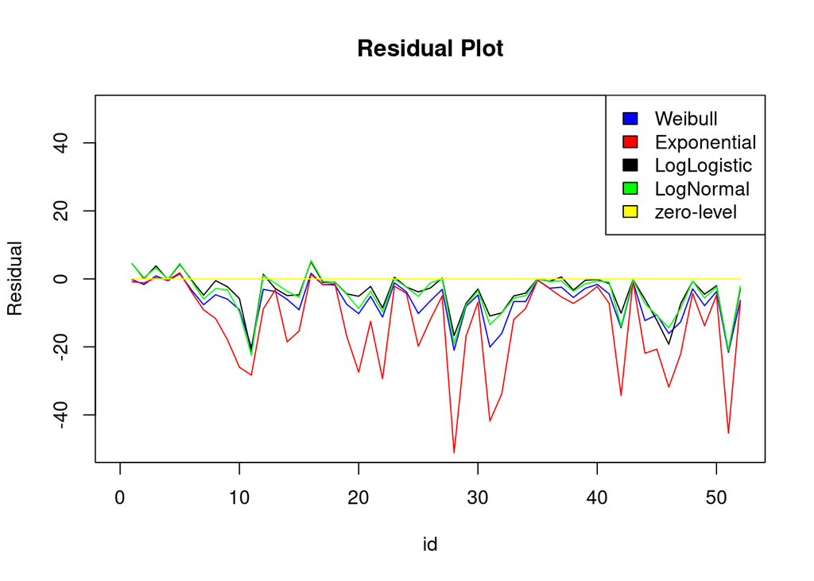

```r
plot(id,test_df$res_w,main = 'Residual Plot',ylab = 'Residual',type = 'l',col = 'blue',xlim=c(0,52),ylim = c(-50,50))
lines(id,test_df$res_e,col = 'red')
lines(id,test_df$res_ll,col = 'black')
lines(id,test_df$res_ln,col = 'green')
lines(id,zeros,col = 'yellow')
legend('topright',c('Weibull','Exponential','LogLogistic','LogNormal','zero-level'),fill = c('blue','red','black','green','yellow'))
```

### Errors

```r
w_error <- sum(abs(test_df$res_w))
e_error <- sum(abs(test_df$res_e))
ll_error <- sum(abs(test_df$res_ll))
ln_error <- sum(abs(test_df$res_ln))

c("Weibull Error - ", w_error)
```

```
## [1] "Weibull Error - " "353.745565367937"
```

```r
c("Exponential Error - ",e_error)
```

```
## [1] "Exponential Error - " "688.976054806401"
```

```r
c("LogLogistic Error - ",ll_error)
```

```
## [1] "LogLogistic Error - " "248.688186208371"
```

```r
c("Log Normal Error - ",ln_error)
```

```
## [1] "Log Normal Error - " "270.55415342"
```

Log logistic model is the best fit among the parametric regression models. This is also supported by the log likelihood values obtained after fitting various probability distributions. (Weibull is the first best fit and log logistic is the second best fit)

#Mixture Model

A mixture model is a collection of probability distributions or densities D1, …, Dk and mixing weights or proportions w1, …, wk, where k is the number of component distributions

The mixture model, P(x|D1,…,Dk,w1,…,wk) = ∑ wj*P(x|Dj) j= 1 to k

Likelihood :

exact lifetimes : f (x) right-censored observations : S (C_r ) left-censored observations : 1 - S (C_l ) interval-censored observations : [S (L) - S (R)] left-truncated observations : f (x)/ S (Y_L ) right-truncated observations : f (x)/ [1 - S (Y_R) ] interval-truncated observations : f (x)/ [S (Y_L) - S (Y_R)

However, PBC Dataset consists of only Right Censored observations

The covariates output by the bestcox model are: [bili exempted because it violates PH Assumption] ageD  
albumin ast  
copper edemaM protime stageM

The covariates in importance order output by Random forests model: bili  
copper  
ascites albumin  
edema  
chol ageD  
protime ast stage

Here, Covariates are used to model the mean/shape parameter in the component distributions. Numbers of mixtures is varied from 2 to 8 and optimal value is determined by the mixture model with least log likelihood value.

```r
pbcData2 <- subset(pbc, status != 1)
pbcData2 = pbcData2[complete.cases(pbcData2), ]
pbcData2 <- mutate(pbcData2, time = (pbcData2$time / 365.25))
pbcData2 <- mutate(pbcData2, ast = (pbcData2$ast / 100))
pbcData2 <- mutate(pbcData2, copper = (pbcData2$copper / 50))
pbcData2 <- mutate(pbcData2, chol = (pbcData2$chol / 200))
pbcData2 <- mutate(pbcData2, bili = (pbcData2$bili / 2))
pbcData2 <- mutate(pbcData2, protime = (pbcData2$protime / 4))
pbcData2$status[pbcData2$status==2] <- 1
pbcData2<- mutate(pbcData2,ageD = age/10)
pbcData2
```

```
##      id       time status trt      age sex ascites hepato spiders edema  bili
## 1     1  1.0951403      1   1 58.76523   f       1      1       1   1.0  7.25
## 2     2 12.3203285      0   1 56.44627   f       0      1       1   0.0  0.55
## 3     3  2.7707050      1   1 70.07255   m       0      0       0   0.5  0.70
## 4     4  5.2703628      1   1 54.74059   f       0      1       1   0.5  0.90
## 5     7  5.0157426      0   2 55.53457   f       0      1       0   0.0  0.50
## 6     8  6.7515400      1   2 53.05681   f       0      0       0   0.0  0.15
## 7     9  6.5708419      1   1 42.50787   f       0      0       1   0.0  1.60
## 8    10  0.1396304      1   2 70.55989   f       1      0       1   1.0  6.30
## 9    11 10.2997947      1   2 53.71389   f       0      1       1   0.0  0.70
## 10   12  0.8323066      1   2 59.13758   f       0      0       1   0.0  1.80
## 11   13  9.7932923      0   2 45.68925   f       0      0       0   0.0  0.35
## 12   15  9.8124572      1   1 64.64613   f       0      0       0   0.0  0.40
## 13   16 10.0533881      0   2 40.44353   f       0      0       0   0.0  0.35
## 14   17  2.1054073      1   2 52.18344   f       0      1       0   0.0  1.35
```

[output cut: 503 more lines]

```r
summary(pbcData2)
```

```
##        id              time             status            trt
##  Min.   :  1.00   Min.   : 0.1123   Min.   :0.0000   Min.   :1.000
##  1st Qu.: 76.25   1st Qu.: 3.3292   1st Qu.:0.0000   1st Qu.:1.000
##  Median :153.50   Median : 5.0075   Median :0.0000   Median :2.000
##  Mean   :155.12   Mean   : 5.5080   Mean   :0.4302   Mean   :1.508
##  3rd Qu.:232.75   3rd Qu.: 7.5873   3rd Qu.:1.0000   3rd Qu.:2.000
##  Max.   :312.00   Max.   :12.4736   Max.   :1.0000   Max.   :2.000
##       age        sex        ascites            hepato          spiders
##  Min.   :26.28   m: 31   Min.   :0.00000   Min.   :0.0000   Min.   :0.0000
##  1st Qu.:42.83   f:227   1st Qu.:0.00000   1st Qu.:0.0000   1st Qu.:0.0000
##  Median :50.41           Median :0.00000   Median :1.0000   Median :0.0000
##  Mean   :50.43           Mean   :0.07364   Mean   :0.5039   Mean   :0.2907
##  3rd Qu.:57.02           3rd Qu.:0.00000   3rd Qu.:1.0000   3rd Qu.:1.0000
##  Max.   :78.44           Max.   :1.00000   Max.   :1.0000   Max.   :1.0000
##      edema             bili             chol          albumin
##  Min.   :0.0000   Min.   : 0.150   Min.   :0.600   Min.   :1.960
##  1st Qu.:0.0000   1st Qu.: 0.400   1st Qu.:1.236   1st Qu.:3.310
##  Median :0.0000   Median : 0.675   Median :1.518   Median :3.540
##  Mean   :0.1105   Mean   : 1.671   Mean   :1.833   Mean   :3.511
##  3rd Qu.:0.0000   3rd Qu.: 1.788   3rd Qu.:1.999   3rd Qu.:3.770
##  Max.   :1.0000   Max.   :14.000   Max.   :8.875   Max.   :4.400
##      copper          alk.phos            ast              trig
##  Min.   : 0.080   Min.   :  289.0   Min.   :0.2838   Min.   : 44.0
##  1st Qu.: 0.825   1st Qu.:  919.5   1st Qu.:0.8204   1st Qu.: 85.0
##  Median : 1.460   Median : 1277.5   Median :1.1547   Median :108.0
##  Mean   : 1.984   Mean   : 2030.6   Mean   :1.2369   Mean   :124.4
##  3rd Qu.: 2.595   3rd Qu.: 2100.5   3rd Qu.:1.5345   3rd Qu.:151.8
##  Max.   :11.760   Max.   :13862.4   Max.   :4.5725   Max.   :598.0
##     platelet        protime          stage            ageD
##  Min.   : 62.0   Min.   :2.250   Min.   :1.000   Min.   :2.628
##  1st Qu.:199.2   1st Qu.:2.500   1st Qu.:2.000   1st Qu.:4.283
##  Median :253.5   Median :2.650   Median :3.000   Median :5.041
##  Mean   :259.5   Mean   :2.690   Mean   :3.027   Mean   :5.043
##  3rd Qu.:318.8   3rd Qu.:2.800   3rd Qu.:4.000   3rd Qu.:5.702
##  Max.   :563.0   Max.   :4.275   Max.   :4.000   Max.   :7.844
```

```r
mm_df <- data_frame(pbcData2$time,
                    pbcData2$status,
                    pbcData2$ageD,
                    pbcData2$albumin,
                    pbcData2$ast,
                    pbcData2$bili,
                    pbcData2$copper,
                    pbcData2$edema,
                    pbcData2$protime,
                    pbcData2$stage,
                    pbcData2$ascites,
                    pbcData2$chol)
names(mm_df) <- c("time","status","ageD","albumin","ast","bili","copper","edema","protime","stage",'ascites','chol')
mm_df
```

```
## # A tibble: 258 x 12
##      time status  ageD albumin   ast  bili copper edema protime stage ascites
##     <dbl>  <dbl> <dbl>   <dbl> <dbl> <dbl>  <dbl> <dbl>   <dbl> <int>   <int>
##  1  1.10       1  5.88    2.6  1.38   7.25   3.12   1      3.05     4       1
##  2 12.3        0  5.64    4.14 1.14   0.55   1.08   0      2.65     3       0
##  3  2.77       1  7.01    3.48 0.961  0.7    4.2    0.5    3        4       0
##  4  5.27       1  5.47    2.54 0.606  0.9    1.28   0.5    2.58     4       0
##  5  5.02       0  5.55    4.09 0.604  0.5    1.04   0      2.42     3       0
##  6  6.75       1  5.31    4    0.284  0.15   1.04   0      2.75     3       0
##  7  6.57       1  4.25    3.08 1.44   1.6    1.58   0      2.75     2       0
##  8  0.140      1  7.06    2.74 1.47   6.3    2.8    1      2.88     4       1
##  9 10.3        1  5.37    4.16 0.790  0.7    0.92   0      3        4       0
## 10  0.832      1  5.91    3.52 0.822  1.8    1.88   0      3.4      4       0
## # … with 248 more rows, and 1 more variable: chol <dbl>
```

## Lognormal with best cox model covariates

```r
# choosing the number of mixtures
  ll <- function(par,x) {
      t = x[,1]
      C_r = x[,2]
      ageD = x[,3]
      albumin = x[,4]
      ast = x[,5]
      bili = x[,6]
      copper = x[,7]
      edema = x[,8]
      protime = x[,9]
      stage = x[,10]
      ascites = x[,11]
      chol= x[,12]
      j = 1
      k = 1
      f_t = 0
      F_t = 0
      div = 0
      while (j <= i){
        f_t = f_t + (par[k]*dlnorm(t,par[k+1]*ageD+
                                   par[k+2]*albumin+
                                   par[k+3]*ast+
                                   par[k+4]*copper+
                                   par[k+5]*edema+
                                   par[k+6]*protime+
                                   par[k+7]*stage,
                                   par[k+8]))
        F_t = F_t + (par[k]*plnorm(t,par[k+1]*ageD+
                                   par[k+2]*albumin+
                                   par[k+3]*ast+
                                   par[k+4]*copper+
                                   par[k+5]*edema+
                                   par[k+6]*protime+
                                   par[k+7]*stage,
                                   par[k+8]))
        div = div + par[k]
        j=j+1
        k=k+9
      }
    f_t = f_t/div
    F_t = F_t/div
    S_t = 1-F_t

    R = (1-C_r)*f_t + C_r*S_t

    -sum(log(R))
    }
  n_mixtures = seq(2,8)

  set.seed(11)

  X = mm_df[['time']]
  mux_init = mean(X)
  sdx_init = sd(X)

  C_r =  mm_df[['status']]
  mucr_init = mean(C_r)
  sdcr_init = sd(C_r)


  data1 = cbind(X,C_r,mm_df[['ageD']],mm_df[['albumin']],mm_df[['ast']],mm_df[['bili']],mm_df[['copper']],mm_df[['edema']],mm_df[['protime']],mm_df[['stage']],mm_df[['ascites']],mm_df[['chol']])

  p = c(0.5,0.1,0.1,0.1,0.1,0.1,0.1,0.1,sdx_init)
  l = c(0,-1,-1,-1,-1,-1,-1,-1,0)
  u = c(1,1,1,1,1,1,1,1,Inf)
  res = c(0)
  for (i in n_mixtures){
    p <- append(p,c(0.1*i,0.1*i,0.1*i,0.1*i,0.1*i,0.1*i,0.1*i,0.1*i,sdx_init*0.1*i))
    l <- append(l,c(0,-1,-1,-1,-1,-1,-1,-1,0))
    u <- append(u,c(1,1,1,1,1,1,1,1,Inf))
    result <- optim(par = p,ll,x=data1,method = "L-BFGS-B", lower = l, upper = u)
    res <- append(res,result)
  }
  print(res)
```

```
## [[1]]
## [1] 0
##
## $par
##  [1]  0.000000000  0.449037039  0.334335615  0.192500507  0.256486858
##  [6]  0.110077802  0.291342117  0.311693361  2.876133766  1.000000000
## [11]  0.026798121  0.173999343  0.057041376  0.002971425  0.172374775
## [16]  0.463425832 -0.046779017  0.416102020
##
## $value
## [1] 376.7487
##
## $counts
## function gradient
##      108      108
##
## $convergence
## [1] 0
##
## $message
## [1] "CONVERGENCE: REL_REDUCTION_OF_F <= FACTR*EPSMCH"
##
## $par
##  [1]  0.000000000  0.328462023  0.255769000  0.162358310  0.196419584
##  [6]  0.107295207  0.228958432  0.239220860  2.885932306  1.000000000
## [11]  0.026782556  0.173934524  0.056993489  0.002954366  0.172368179
## [16]  0.463586146 -0.046791648  0.416091573  0.000000000 -0.061194865
## [21]  0.019439887  0.214633580  0.190877138  0.298644138  0.102584880
## [26]  0.083239500  0.957686957
##
## $value
## [1] 376.7487
##
## $counts
## function gradient
##      108      108
##
## $convergence
## [1] 0
##
```

[output cut: 118 more lines]

```
## [66]  0.799080526  0.799805229  0.799815547  0.799999684  0.799319096
## [71]  0.799645940  2.469109846
##
## $value
## [1] 363.2737
##
## $counts
## function gradient
##      113      113
##
## $convergence
## [1] 1
##
## $message
## [1] "NEW_X"
```

##Lognormal with Random forests covariates

```r
# choosing the number of mixtures
  ll <- function(par,x) {
      t = x[,1]
      C_r = x[,2]
      ageD = x[,3]
      albumin = x[,4]
      ast = x[,5]
      bili = x[,6]
      copper = x[,7]
      edema = x[,8]
      protime = x[,9]
      stage = x[,10]
      ascites = x[,11]
      chol= x[,12]
      j = 1
      k = 1
      f_t = 0
      F_t = 0
      div = 0
      while (j <= i){
        f_t = f_t + (par[k]*dlnorm(t,par[k+1]*ageD+
                                   par[k+2]*albumin+
                                   par[k+3]*ast+
                                   par[k+4]*copper+
                                   par[k+5]*edema+
                                   par[k+6]*protime+
                                   par[k+7]*stage+
                                   par[k+8]*ascites+
                                   par[k+9]*bili+
                                   par[k+10]*chol,
                                   par[k+11]))
        F_t = F_t + (par[k]*plnorm(t,par[k+1]*ageD+
                                   par[k+2]*albumin+
                                   par[k+3]*ast+
                                   par[k+4]*copper+
                                   par[k+5]*edema+
                                   par[k+6]*protime+
                                   par[k+7]*stage+
                                   par[k+8]*ascites+
                                   par[k+9]*bili+
                                   par[k+10]*chol,
                                   par[k+11]))
        div = div + par[k]
        j=j+1
        k=k+12
      }
    f_t = f_t/div
    F_t = F_t/div
    S_t = 1-F_t

    R = (1-C_r)*f_t + C_r*S_t

    -sum(log(R))
    }
  n_mixtures = seq(2,8)

  set.seed(11)

  X = mm_df[['time']]
  mux_init = mean(X)
  sdx_init = sd(X)

  C_r =  mm_df[['status']]
  mucr_init = mean(C_r)
  sdcr_init = sd(C_r)


  data1 = cbind(X,C_r,mm_df[['ageD']],mm_df[['albumin']],mm_df[['ast']],mm_df[['bili']],mm_df[['copper']],mm_df[['edema']],mm_df[['protime']],mm_df[['stage']],mm_df[['ascites']],mm_df[['chol']])

  p = c(0.5,0.1,0.1,0.1,0.1,0.1,0.1,0.1,0.1,0.1,0.1,sdx_init)
  l = c(0,-1,-1,-1,-1,-1,-1,-1,-1,-1,-1,0)
  u = c(1,1,1,1,1,1,1,1,1,1,1,Inf)
  res = c(0)
  for (i in n_mixtures){
    p <- append(p,c(0.1*i,0.1*i,0.1*i,0.1*i,0.1*i,0.1*i,0.1*i,0.1*i,0.1*i,0.1*i,0.1*i,sdx_init*0.1*i))
    l <- append(l,c(0,-1,-1,-1,-1,-1,-1,-1,-1,-1,-1,0))
    u <- append(u,c(1,1,1,1,1,1,1,1,1,1,1,Inf))
    result <- optim(par = p,ll,x=data1,method = "L-BFGS-B", lower = l, upper = u)
    res <- append(res,result)
  }
  print(res)
```

```
## [[1]]
## [1] 0
##
## $par
##  [1]  0.00000000  0.29276189  0.21872885  0.14125283  0.18420570  0.10730290
##  [7]  0.20479195  0.21137715  0.10338303  0.17721674  0.15754205  2.80949161
## [13]  0.88890195  0.02337850  0.16646346  0.08187367  0.01349726  0.23183535
## [19]  0.46679675 -0.04210709  0.13854463 -0.05429422  0.01378523  0.40781308
##
## $value
## [1] 375.1093
##
## $counts
## function gradient
##      124      124
##
## $convergence
## [1] 1
##
## $message
## [1] "NEW_X"
##
## $par
##  [1]  0.00000000  0.20840878  0.16414705  0.11862509  0.14304453  0.10597106
##  [7]  0.16233718  0.16078663  0.10298899  0.13948553  0.12110745  2.82819468
## [13]  1.00000000  0.02345057  0.16708111  0.08226209  0.01349129  0.23026033
## [19]  0.46562493 -0.04199954  0.13868469 -0.05417871  0.01357866  0.40774280
## [25]  0.00000000  0.19421192  0.21453877  0.28005347  0.28053188  0.29962375
## [31]  0.23922576  0.24911606  0.30000284  0.29147555  0.26985554  0.95839844
##
## $value
## [1] 375.1093
##
## $counts
## function gradient
##      120      120
##
## $convergence
## [1] 1
##
```

[output cut: 134 more lines]

```
## [91]  0.799687064  0.799845022  0.800000000  0.799958312  0.799884035
## [96]  2.468750574
##
## $value
## [1] 363.0438
##
## $counts
## function gradient
##      111      111
##
## $convergence
## [1] 1
##
## $message
## [1] "NEW_X"
```

## Normal with best cox model covariates

```r
# choosing the number of mixtures
  ll <- function(par,x) {
      t = x[,1]
      C_r = x[,2]
      ageD = x[,3]
      albumin = x[,4]
      ast = x[,5]
      bili = x[,6]
      copper = x[,7]
      edema = x[,8]
      protime = x[,9]
      stage = x[,10]
      ascites = x[,11]
      chol= x[,12]
      j = 1
      k = 1
      f_t = 0
      F_t = 0
      div = 0
      while (j <= i){
        f_t = f_t + (par[k]*dnorm(t,par[k+1]*ageD+
                                   par[k+2]*albumin+
                                   par[k+3]*ast+
                                   par[k+4]*copper+
                                   par[k+5]*edema+
                                   par[k+6]*protime+
                                   par[k+7]*stage,
                                   par[k+8]))
        F_t = F_t + (par[k]*pnorm(t,par[k+1]*ageD+
                                   par[k+2]*albumin+
                                   par[k+3]*ast+
                                   par[k+4]*copper+
                                   par[k+5]*edema+
                                   par[k+6]*protime+
                                   par[k+7]*stage,
                                   par[k+8]))
        div = div + par[k]
        j=j+1
        k=k+9
      }
    f_t = f_t/div
    F_t = F_t/div
    S_t = 1-F_t

    R = (1-C_r)*f_t + C_r*S_t

    -sum(log(R))
    }
  n_mixtures = seq(2,8)

  set.seed(11)

  X = mm_df[['time']]
  mux_init = mean(X)
  sdx_init = sd(X)

  C_r =  mm_df[['status']]
  mucr_init = mean(C_r)
  sdcr_init = sd(C_r)


  data1 = cbind(X,C_r,mm_df[['ageD']],mm_df[['albumin']],mm_df[['ast']],mm_df[['bili']],mm_df[['copper']],mm_df[['edema']],mm_df[['protime']],mm_df[['stage']],mm_df[['ascites']],mm_df[['chol']])

  p = c(0.5,0.1,0.1,0.1,0.1,0.1,0.1,0.1,sdx_init)
  l = c(0,-1,-1,-1,-1,-1,-1,-1,0)
  u = c(1,1,1,1,1,1,1,1,Inf)
  res = c(0)
  for (i in n_mixtures){
    p <- append(p,c(0.1*i,0.1*i,0.1*i,0.1*i,0.1*i,0.1*i,0.1*i,0.1*i,sdx_init*0.1*i))
    l <- append(l,c(0,-1,-1,-1,-1,-1,-1,-1,0))
    u <- append(u,c(1,1,1,1,1,1,1,1,Inf))
    result <- optim(par = p,ll,x=data1,method = "L-BFGS-B", lower = l, upper = u)
    res <- append(res,result)
  }
  print(res)
```

```
## [[1]]
## [1] 0
##
## $par
##  [1]  0.63252449  0.46930507  0.90440982  0.43428653  0.58712593  1.00000000
##  [7]  1.00000000 -0.27074405  2.26522190  0.30180916  0.04409056  0.70483025
## [13] -0.28358155  0.03745709 -0.29674265  0.42060492  0.29780967  0.98199743
##
## $value
## [1] 374.0854
##
## $counts
## function gradient
##      113      113
##
## $convergence
## [1] 1
##
## $message
## [1] "NEW_X"
##
## $par
##  [1]  0.881688196  0.764250946  0.011060913  0.370332745  0.683935511
##  [6]  0.740191981  1.000000000 -0.087899126  1.232323829  0.651931844
## [11]  0.073233266  0.475174487 -0.285541354  0.060174149 -0.429421518
## [16]  0.602457741  0.300266774  0.886871599  0.499608990  0.846614295
## [21]  1.000000000 -0.008270595  1.000000000  0.049591773  1.000000000
## [26] -0.117572355  0.856697745
##
## $value
## [1] 366.2231
##
## $counts
## function gradient
##      105      105
##
## $convergence
## [1] 1
##
## $message
```

[output cut: 107 more lines]

```
## [61]  1.00000000  0.02495581  1.83622971  0.87233273  0.35268777  1.00000000
## [67]  0.83387742  0.69313145  0.78594027  1.00000000 -0.01310232  1.91711843
##
## $value
## [1] 354.1882
##
## $counts
## function gradient
##      121      121
##
## $convergence
## [1] 1
##
## $message
## [1] "NEW_X"
```

Observations - Best Model : Mixtures of 5 Normal models Loglikelihood : -349.5825

##Normal with Random forests covariates

```r
# choosing the number of mixtures
  ll <- function(par,x) {
      t = x[,1]
      C_r = x[,2]
      ageD = x[,3]
      albumin = x[,4]
      ast = x[,5]
      bili = x[,6]
      copper = x[,7]
      edema = x[,8]
      protime = x[,9]
      stage = x[,10]
      ascites = x[,11]
      chol= x[,12]
      j = 1
      k = 1
      f_t = 0
      F_t = 0
      div = 0
      while (j <= i){
        f_t = f_t + (par[k]*dnorm(t,par[k+1]*ageD+
                                   par[k+2]*albumin+
                                   par[k+3]*ast+
                                   par[k+4]*copper+
                                   par[k+5]*edema+
                                   par[k+6]*protime+
                                   par[k+7]*stage+
                                   par[k+8]*ascites+
                                   par[k+9]*bili+
                                   par[k+10]*chol,
                                   par[k+11]))
        F_t = F_t + (par[k]*pnorm(t,par[k+1]*ageD+
                                   par[k+2]*albumin+
                                   par[k+3]*ast+
                                   par[k+4]*copper+
                                   par[k+5]*edema+
                                   par[k+6]*protime+
                                   par[k+7]*stage+
                                   par[k+8]*ascites+
                                   par[k+9]*bili+
                                   par[k+10]*chol,
                                   par[k+11]))
        div = div + par[k]
        j=j+1
        k=k+12
      }
    f_t = f_t/div
    F_t = F_t/div
    S_t = 1-F_t

    R = (1-C_r)*f_t + C_r*S_t

    -sum(log(R))
    }
  n_mixtures = seq(2,8)

  set.seed(11)

  X = mm_df[['time']]
  mux_init = mean(X)
  sdx_init = sd(X)

  C_r =  mm_df[['status']]
  mucr_init = mean(C_r)
  sdcr_init = sd(C_r)


  data1 = cbind(X,C_r,mm_df[['ageD']],mm_df[['albumin']],mm_df[['ast']],mm_df[['bili']],mm_df[['copper']],mm_df[['edema']],mm_df[['protime']],mm_df[['stage']],mm_df[['ascites']],mm_df[['chol']])

  p = c(0.5,0.1,0.1,0.1,0.1,0.1,0.1,0.1,0.1,0.1,0.1,sdx_init)
  l = c(0,-1,-1,-1,-1,-1,-1,-1,-1,-1,-1,0)
  u = c(1,1,1,1,1,1,1,1,1,1,1,Inf)
  res = c(0)
  for (i in n_mixtures){
    p <- append(p,c(0.1*i,0.1*i,0.1*i,0.1*i,0.1*i,0.1*i,0.1*i,0.1*i,0.1*i,0.1*i,0.1*i,sdx_init*0.1*i))
    l <- append(l,c(0,-1,-1,-1,-1,-1,-1,-1,-1,-1,-1,0))
    u <- append(u,c(1,1,1,1,1,1,1,1,1,1,1,Inf))
    result <- optim(par = p,ll,x=data1,method = "L-BFGS-B", lower = l, upper = u)
    res <- append(res,result)
  }
  print(res)
```

```
## [[1]]
## [1] 0
##
## $par
##  [1]  0.77089053  0.53228682  0.88494385  0.88741202  0.39382298  1.00000000
##  [7]  1.00000000 -0.44373544  1.00000000  0.08961933 -0.39961274  2.39718336
## [13]  0.18133171  0.09617261  0.56131894 -0.15519687  0.07817129  0.07949221
## [19]  0.04941967  0.64415969  0.75365664 -0.36041515 -0.02060361  0.53231727
##
## $value
## [1] 371.4772
##
## $counts
## function gradient
##      110      110
##
## $convergence
## [1] 1
##
## $message
## [1] "NEW_X"
##
## $par
##  [1]  0.858324442  0.132110599  0.779804486  0.680469047 -0.050149552
##  [6]  0.916465574  0.997570299 -0.345679216  0.422008191 -0.213370097
## [11] -0.001432490  1.279972010  0.243290027  0.072757535  0.773488460
## [16] -0.346287248  0.052228831  0.241613201 -0.525049899  1.000000000
## [21]  0.838164701 -0.355508424 -0.036398626  0.234029487  1.000000000
## [26]  0.188018296  0.997843686  0.973168898  0.395635225  0.652697162
## [31]  1.000000000  0.005202769  0.742266224  0.856309273  0.305395935
## [36]  1.852361585
##
## $value
## [1] 360.6974
##
## $counts
## function gradient
##      108      108
##
## $convergence
```

[output cut: 129 more lines]

```
## [85]  0.78407266  0.12802803  0.82196839  0.82240561  0.65552562  0.80377137
## [91]  1.00000000 -0.01942784  0.83087895  0.71444924  0.47671631  2.07214535
##
## $value
## [1] 346.9611
##
## $counts
## function gradient
##      111      111
##
## $convergence
## [1] 1
##
## $message
## [1] "NEW_X"
```

Observations - Best Model : Mixtures of 7 Normal models Loglikelihood : -343.0989

## Loglogistic with best cox model covariates

```r
# choosing the number of mixtures
  ll <- function(par,x) {
      t = x[,1]
      C_r = x[,2]
      ageD = x[,3]
      albumin = x[,4]
      ast = x[,5]
      bili = x[,6]
      copper = x[,7]
      edema = x[,8]
      protime = x[,9]
      stage = x[,10]
      ascites = x[,11]
      chol= x[,12]
      j = 1
      k = 1
      f_t = 0
      F_t = 0
      div = 0
      while (j <= i){
        f_t = f_t + (par[k]*dllogis(t,shape = par[k+1]*ageD+
                                   par[k+2]*albumin+
                                   par[k+3]*ast+
                                   par[k+4]*copper+
                                   par[k+5]*edema+
                                   par[k+6]*protime+
                                   par[k+7]*stage,
                                   scale = par[k+8]))
        F_t = F_t + (par[k]*pllogis(t,shape = par[k+1]*ageD+
                                   par[k+2]*albumin+
                                   par[k+3]*ast+
                                   par[k+4]*copper+
                                   par[k+5]*edema+
                                   par[k+6]*protime+
                                   par[k+7]*stage,
                                   scale = par[k+8]))
        div = div + par[k]
        j=j+1
        k=k+9
      }
    f_t = f_t/div
    F_t = F_t/div
    S_t = 1-F_t

    R = (1-C_r)*f_t + C_r*S_t

    -sum(log(R))
    }
  n_mixtures = seq(2,8)

  set.seed(11)

  X = mm_df[['time']]
  mux_init = mean(X)
  sdx_init = sd(X)

  C_r =  mm_df[['status']]
  mucr_init = mean(C_r)
  sdcr_init = sd(C_r)


  data1 = cbind(X,C_r,mm_df[['ageD']]/50,mm_df[['albumin']]/50,mm_df[['ast']]/50,mm_df[['bili']]/50,mm_df[['copper']]/50,mm_df[['edema']]/50,mm_df[['protime']]/50,mm_df[['stage']]/50,mm_df[['ascites']]/50,mm_df[['chol']]/50)

  p = c(0.5,0.01,0.02,0.03,0.04,0.05,0.06,0.07,0.5)
  l = c(0,-1,-1,-1,-1,-1,-1,-1,0)
  u = c(1,1,1,1,1,1,1,1,Inf)
  res = c(0)
  for (i in n_mixtures){
    p <- append(p,c(0.1*i,0.01*i,0.02*i,0.03*i,0.04*i,0.05*i,0.06*i,0.07*i,0.05*i))
    l <- append(l,c(0,-1,-1,-1,-1,-1,-1,-1,0))
    u <- append(u,c(1,1,1,1,1,1,1,1,Inf))
    result <- optim(par = p,ll,x=data1,method = "L-BFGS-B", lower = l, upper = u)
    res <- append(res,result)
  }
  print(res)
```

```
## [[1]]
## [1] 0
##
## $par
##  [1]  0.0000000  0.1789242  0.4487968  1.0000000  0.9872305  1.0000000
##  [7]  0.6721019  0.6530073  2.0116995  1.0000000  1.0000000  1.0000000
## [13]  1.0000000  1.0000000  1.0000000  1.0000000  1.0000000 28.9768675
##
## $value
## [1] 683.1873
##
## $counts
## function gradient
##       18       18
##
## $convergence
## [1] 0
##
## $message
## [1] "CONVERGENCE: REL_REDUCTION_OF_F <= FACTR*EPSMCH"
##
## $par
##  [1]  0.0000000000 -0.0005926157  0.4131373349  1.0000000000  1.0000000000
##  [6]  1.0000000000  0.7451635806  0.7146336843  1.9234037789  0.0000000000
## [11]  1.0000000000  1.0000000000  1.0000000000  1.0000000000  1.0000000000
## [16]  1.0000000000  1.0000000000  9.2456418612  1.0000000000  1.0000000000
## [21]  1.0000000000  1.0000000000  1.0000000000  1.0000000000  1.0000000000
## [26]  1.0000000000 28.9768673855
##
## $value
## [1] 683.1873
##
## $counts
## function gradient
##       22       22
##
## $convergence
## [1] 0
##
## $message
```

[output cut: 107 more lines]

```
## [61]  1.0000000  1.0000000  6.8043847  1.0000000  1.0000000  1.0000000
## [67]  1.0000000  1.0000000  1.0000000  1.0000000  1.0000000 28.9768289
##
## $value
## [1] 683.1873
##
## $counts
## function gradient
##       35       35
##
## $convergence
## [1] 0
##
## $message
## [1] "CONVERGENCE: REL_REDUCTION_OF_F <= FACTR*EPSMCH"
```

Observations - Best Model : Mixtures of 2 Log Logistic models Loglikelihood : -683.1873

##LogLogistic with Random forest covariates

```r
# choosing the number of mixtures
  ll <- function(par,x) {
      t = x[,1]
      C_r = x[,2]
      ageD = x[,3]
      albumin = x[,4]
      ast = x[,5]
      bili = x[,6]
      copper = x[,7]
      edema = x[,8]
      protime = x[,9]
      stage = x[,10]
      ascites = x[,11]
      chol= x[,12]
      j = 1
      k = 1
      f_t = 0
      F_t = 0
      div = 0
      while (j <= i){
        f_t = f_t + (par[k]*dllogis(t,par[k+1]*ageD+
                                   par[k+2]*albumin+
                                   par[k+3]*ast+
                                   par[k+4]*copper+
                                   par[k+5]*edema+
                                   par[k+6]*protime+
                                   par[k+7]*stage+
                                   par[k+8]*ascites+
                                   par[k+9]*bili+
                                   par[k+10]*chol,
                                   scale = par[k+11]))
        F_t = F_t + (par[k]*pllogis(t,par[k+1]*ageD+
                                   par[k+2]*albumin+
                                   par[k+3]*ast+
                                   par[k+4]*copper+
                                   par[k+5]*edema+
                                   par[k+6]*protime+
                                   par[k+7]*stage+
                                   par[k+8]*ascites+
                                   par[k+9]*bili+
                                   par[k+10]*chol,
                                   scale = par[k+11]))
        div = div + par[k]
        j=j+1
        k=k+12
      }
    f_t = f_t/div
    F_t = F_t/div
    S_t = 1-F_t

    R = (1-C_r)*f_t + C_r*S_t

    -sum(log(R))
    }
  n_mixtures = seq(2,8)

  set.seed(11)

  X = mm_df[['time']]
  mux_init = mean(X)
  sdx_init = sd(X)

  C_r =  mm_df[['status']]
  mucr_init = mean(C_r)
  sdcr_init = sd(C_r)


  data1 = cbind(X,C_r,mm_df[['ageD']]/100,mm_df[['albumin']]/100,mm_df[['ast']]/100,mm_df[['bili']]/100,mm_df[['copper']]/100,mm_df[['edema']]/100,mm_df[['protime']]/100,mm_df[['stage']]/100,mm_df[['ascites']]/100,mm_df[['chol']]/100)

  p = c(0.5,0.01,0.02,0.03,0.04,0.05,0.06,0.07,0.08,0.09,0.1,0.5)
  l = c(0,-1,-1,-1,-1,-1,-1,-1,-1,-1,-1,0)
  u = c(1,1,1,1,1,1,1,1,1,1,1,Inf)
  res = c(0)
  for (i in n_mixtures){
    p <- append(p,c(0.1*i,0.01*i,0.02*i,0.03*i,0.04*i,0.05*i,0.06*i,0.07*i,0.08*i,0.09*i,0.1*i,0.05*i))
    l <- append(l,c(0,-1,-1,-1,-1,-1,-1,-1,-1,-1,-1,0))
    u <- append(u,c(1,1,1,1,1,1,1,1,1,1,1,Inf))
    result <- optim(par = p,ll,x=data1,method = "L-BFGS-B", lower = l, upper = u)
    res <- append(res,result)
  }
  print(res)
```

```
## [[1]]
## [1] 0
##
## $par
##  [1]   0.0000000   0.1240407   0.3567034   0.8648367   0.8269107   1.0000000
##  [7]   0.5552575   0.5391929   0.4522641   0.9379426   0.7623677   1.5191649
## [13]   0.9117536   1.0000000   1.0000000   1.0000000   1.0000000   1.0000000
## [19]   1.0000000   1.0000000   1.0000000   1.0000000   1.0000000 110.2328105
##
## $value
## [1] 765.6595
##
## $counts
## function gradient
##       22       22
##
## $convergence
## [1] 0
##
## $message
## [1] "CONVERGENCE: REL_REDUCTION_OF_F <= FACTR*EPSMCH"
##
## $par
##  [1]   0.00000000  -0.54720786   0.08960116   1.00000000   1.00000000
##  [6]   1.00000000   0.60550284   0.55317044   0.42860098   1.00000000
## [11]   1.00000000   1.88848740   0.00000000   1.00000000   1.00000000
## [16]   1.00000000   1.00000000   1.00000000   1.00000000   1.00000000
## [21]   0.31216461   1.00000000   1.00000000  10.50257425   1.00000000
## [26]   1.00000000   1.00000000   1.00000000   1.00000000   1.00000000
## [31]   1.00000000   1.00000000   1.00000000   1.00000000   1.00000000
## [36] 110.23285971
##
## $value
## [1] 765.6595
##
## $counts
## function gradient
##       29       29
##
## $convergence
```

[output cut: 131 more lines]

```
## [91]   1.00000000   1.00000000   1.00000000   1.00000000   1.00000000
## [96] 110.23214606
##
## $value
## [1] 765.6595
##
## $counts
## function gradient
##       39       39
##
## $convergence
## [1] 0
##
## $message
## [1] "CONVERGENCE: REL_REDUCTION_OF_F <= FACTR*EPSMCH"
```

Observations - Best Model : Mixtures of 2 Log Logistic models Loglikelihood : -765.6595

## Weibull with best cox model covariates

```r
# choosing the number of mixtures
  ll <- function(par,x) {
      t = x[,1]
      C_r = x[,2]
      ageD = x[,3]
      albumin = x[,4]
      ast = x[,5]
      bili = x[,6]
      copper = x[,7]
      edema = x[,8]
      protime = x[,9]
      stage = x[,10]
      ascites = x[,11]
      chol= x[,12]
      j = 1
      k = 1
      f_t = 0
      F_t = 0
      div = 0
      while (j <= i){
        f_t = f_t + (par[k]*dweibull(t,shape = par[k+1]*ageD+
                                   par[k+2]*albumin+
                                   par[k+3]*ast+
                                   par[k+4]*copper+
                                   par[k+5]*edema+
                                   par[k+6]*protime+
                                   par[k+7]*stage,
                                   scale = par[k+8]))
        F_t = F_t + (par[k]*pweibull(t,shape = par[k+1]*ageD+
                                   par[k+2]*albumin+
                                   par[k+3]*ast+
                                   par[k+4]*copper+
                                   par[k+5]*edema+
                                   par[k+6]*protime+
                                   par[k+7]*stage,
                                   scale = par[k+8]))
        div = div + par[k]
        j=j+1
        k=k+9
      }
    f_t = f_t/div
    F_t = F_t/div
    S_t = 1-F_t

    R = (1-C_r)*f_t + C_r*S_t

    -sum(log(R))
    }
  n_mixtures = seq(2,8)

  set.seed(11)

  X = mm_df[['time']]
  mux_init = mean(X)
  sdx_init = sd(X)

  C_r =  mm_df[['status']]
  mucr_init = mean(C_r)
  sdcr_init = sd(C_r)


  data1 = cbind(X,C_r,mm_df[['ageD']]/50,mm_df[['albumin']]/50,mm_df[['ast']]/50,mm_df[['bili']]/50,mm_df[['copper']]/50,mm_df[['edema']]/50,mm_df[['protime']]/50,mm_df[['stage']]/50,mm_df[['ascites']]/50,mm_df[['chol']]/50)

  p = c(0.5,0.01,0.02,0.03,0.04,0.05,0.06,0.07,0.5)
  l = c(0,-1,-1,-1,-1,-1,-1,-1,0)
  u = c(1,1,1,1,1,1,1,1,10)
  res = c(0)
  for (i in n_mixtures){
    p <- append(p,c(0.1*i,0.01*i,0.02*i,0.03*i,0.04*i,0.05*i,0.06*i,0.07*i,0.05*i))
    l <- append(l,c(0,-1,-1,-1,-1,-1,-1,-1,0))
    u <- append(u,c(1,1,1,1,1,1,1,1,10))
    result <- optim(par = p,ll,x=data1,method = "L-BFGS-B", lower = l, upper = u)
    res <- append(res,result)
  }
  print(res)
```

```
## [[1]]
## [1] 0
##
## $par
##  [1]  0.00000  1.00000  1.00000  1.00000  1.00000  1.00000  1.00000  1.00000
##  [9]  2.83142  1.00000  1.00000  1.00000  1.00000  1.00000  1.00000  1.00000
## [17]  1.00000 10.00000
##
## $value
## [1] 651.8244
##
## $counts
## function gradient
##        2        2
##
## $convergence
## [1] 0
##
## $message
## [1] "CONVERGENCE: NORM OF PROJECTED GRADIENT <= PGTOL"
##
## $par
##  [1]  0.000000  1.000000  1.000000  1.000000  1.000000  1.000000  1.000000
##  [8]  1.000000  2.252533  0.000000  1.000000  1.000000  1.000000  1.000000
## [15]  0.829231  1.000000  1.000000  8.718719  1.000000  1.000000  1.000000
## [22]  1.000000  1.000000  1.000000  1.000000  1.000000 10.000000
##
## $value
## [1] 651.8244
##
## $counts
## function gradient
##        7        7
##
## $convergence
## [1] 0
##
## $message
## [1] "CONVERGENCE: NORM OF PROJECTED GRADIENT <= PGTOL"
##
```

[output cut: 105 more lines]

```
## [61]  1.0000000  1.0000000 10.0000000  1.0000000  1.0000000  1.0000000
## [67]  1.0000000  1.0000000  1.0000000  1.0000000  1.0000000 10.0000000
##
## $value
## [1] 651.8244
##
## $counts
## function gradient
##       16       16
##
## $convergence
## [1] 0
##
## $message
## [1] "CONVERGENCE: NORM OF PROJECTED GRADIENT <= PGTOL"
```

Observations - Best Model : Mixtures of 2 Weibull models Loglikelihood : -651.8244